PHÂN TÍCH VÀ XÂY DỰNG MÔ HÌNH DỰ ĐOÁN VỚI TẬP DỮ LIỆU BÁN HÀNG PIZZA RESTAURANT SALES Nguyễn Thị Ngọc Hân Nguyễn Hoàng Võ Triệu Phúc Nguyễn Thị Hồng Thơ 2024-11-04

# Phần 1. Tóm tắt

Nghiên cứu này dùng ngôn ngữ R để phân tích và xây dựng mô hình dự đoán trên tập dữ liệu bán hàng pizza trong quá khứ. Các biểu đồ Histogram, Boxplot, Line chart, Bar chart, Pie chart, Scatter plot và WordCloud được ứng dụng để phân tích dữ liệu và trực quan hóa xu hướng trong nhu cầu pizza theo thời gian, tìm ra các thành phần nguyên liệu được thường xuyên sử dụng, thể hiện doanh số, doanh thu của cửa hàng… Đối với doanh số, kiểm định Kruskal-Wallis được dùng để kiểm tra sự biến động doanh số của từng pizza giữa các tháng có đáng kể không và ANOVA được dùng để so sánh sự chênh lệch doanh số giữa các danh mục bánh. Sau đó các mô hình khác nhau đã được sử dụng để thực hiện dự đoán doanh số: Mô hình Hồi quy tuyến tính được chọn do tính đơn giản và khả năng giải thích dễ dàng, trong khi Rừng ngẫu nhiên và GBM được chọn để xử lý các mối quan hệ phức tạp giữa các biến độc lập. Bên cạnh đó, mô hình ARIMA được dùng để dự đoán doanh thu cho 6 tháng tiếp theo.

# Phần 2. Giới thiệu

Dữ liệu được ví như “dầu mỏ của thế kỷ 21” nhờ khả năng thúc đẩy sự đổi mới và cải tiến trong nhiều lĩnh vực. Giá trị của dữ liệu không chỉ nằm ở bản thân các con số, mà còn ở những thông tin có thể khai thác và ứng dụng từ dữ liệu. Đặc biệt trong ngành F&B, khi được thu thập, phân tích và diễn giải đúng cách, dữ liệu bán hàng và hành vi của người tiêu dùng trở thành nguồn tài nguyên chiến lược quan trọng giúp doanh nghiệp đưa ra những quyết định chính xác, giảm thiểu rủi ro và thúc đẩy tăng trưởng. Hơn nữa, phân tích dữ liệu bán hàng sẽ giúp tối ưu hóa hàng tồn kho của doanh nghiệp, giảm tình trạng dư thừa, cũng như có thể tăng số lượng các mặt hàng phổ biến để tránh tình trạng thiếu hàng (sold out) và tối đa hóa doanh số cho doanh nghiệp.

Cùng với những mục đích trên, trong nghiên cứu này, nhóm chúng em thực hiện phân tích tập dữ liệu bán hàng năm 2015 của một cửa hàng pizza và phát triển các mô hình dự đoán doanh số và doanh thu. Từ đó, có thể rút ra những nhận định hữu ích để hỗ trợ việc ra quyết định kinh doanh, tăng cường hiệu quả hoạt động và xây dựng các chiến lược marketing phù hợp.

# Phần 3. Mục tiêu nghiên cứu

Để đạt được mục đích đã nêu trên, nhóm chúng em đặt ra các mục tiêu sau:

- Phân tích và trực quan hóa nhu cầu tiêu thụ pizza theo thời gian, xác định rõ xu hướng tiêu thụ theo các giai đoạn cụ thể như mùa, tháng, tuần, ngày trong tuần và giờ trong ngày.
- Phân tích và trực quan hóa tần suất sử dụng, xác định các nguyên liệu dùng nhiều nhất mỗi tháng.
- Phân tích và trực quan hóa doanh số theo kích cỡ bánh, danh mục bánh, xác định các pizza bán chạy nhất cũng như kém phổ biến nhất trong năm 2015. Xác định các yếu tố ảnh hưởng đến doanh số.
- Xây dựng mô hình dự đoán doanh số của sản phẩm có độ chính xác trên 80%.
- Phân tích và trực quan hóa doanh thu theo thời gian: doanh thu theo giờ, doanh thu theo ngày, doanh thu theo tháng của cửa hàng trong năm 2015.
- Xây dựng mô hình dự đoán doanh thu trong 6 tháng tiếp theo của cửa hàng.

# Phần 4. Thông tin về tập dữ liệu

```r
sales_df <- read_excel("./data/Pizza Sales.xlsx")

head(sales_df)
```

```
## # A tibble: 6 × 12
##   order_details_id order_id pizza_id      quantity order_date
##              <dbl>    <dbl> <chr>            <dbl> <dttm>
## 1                1        1 hawaiian_m           1 2015-01-01 00:00:00
## 2                2        2 classic_dlx_m        1 2015-01-01 00:00:00
## 3                3        2 five_cheese_l        1 2015-01-01 00:00:00
## 4                4        2 ital_supr_l          1 2015-01-01 00:00:00
## 5                5        2 mexicana_m           1 2015-01-01 00:00:00
## 6                6        2 thai_ckn_l           1 2015-01-01 00:00:00
## # ℹ 7 more variables: order_time <dttm>, unit_price <dbl>, total_price <dbl>,
## #   pizza_size <chr>, pizza_category <chr>, pizza_ingredients <chr>,
## #   pizza_name <chr>
```

```r
str(sales_df)
```

```
## tibble [48,620 × 12] (S3: tbl_df/tbl/data.frame)
##  $ order_details_id : num [1:48620] 1 2 3 4 5 6 7 8 9 10 ...
##  $ order_id         : num [1:48620] 1 2 2 2 2 2 3 3 4 5 ...
##  $ pizza_id         : chr [1:48620] "hawaiian_m" "classic_dlx_m" "five_cheese_l" "ital_supr_l" ...
##  $ quantity         : num [1:48620] 1 1 1 1 1 1 1 1 1 1 ...
##  $ order_date       : POSIXct[1:48620], format: "2015-01-01" "2015-01-01" ...
##  $ order_time       : POSIXct[1:48620], format: "1899-12-31 11:38:36" "1899-12-31 11:57:40" ...
##  $ unit_price       : num [1:48620] 13.2 16 18.5 20.8 16 ...
##  $ total_price      : num [1:48620] 13.2 16 18.5 20.8 16 ...
##  $ pizza_size       : chr [1:48620] "M" "M" "L" "L" ...
##  $ pizza_category   : chr [1:48620] "Classic" "Classic" "Veggie" "Supreme" ...
##  $ pizza_ingredients: chr [1:48620] "Sliced Ham, Pineapple, Mozzarella Cheese" "Pepperoni, Mushrooms, Red Onions, Red Peppers, Bacon" "Mozzarella Cheese, Provolone Cheese, Smoked Gouda Cheese, Romano Cheese, Blue Cheese, Garlic" "Calabrese Salami, Capocollo, Tomatoes, Red Onions, Green Olives, Ga…
##  $ pizza_name       : chr [1:48620] "The Hawaiian Pizza" "The Classic Deluxe Pizza" "The Five Cheese Pizza" "The Italian Supreme Pizza" ...
```

Tập dữ liệu Pizza Sales có tổng cộng 48,620 dòng và 12 cột, cung cấp thông tin chi tiết về các đơn hàng bán pizza. Mỗi dòng tương ứng với một mục trong đơn hàng, được xác định bởi order_details_id, và thuộc về một đơn hàng nhận diện qua order_id. Dữ liệu bao gồm các thông tin quan trọng như ngày và giờ đặt hàng, loại pizza, kích cỡ, số lượng, đơn giá… Cụ thể về thông tin của 12 biến và kiểu dữ liệu tương ứng như sau:

- order_details_id: Kiểu số (numeric). Đây là mã định danh duy nhất cho từng dòng trong tập dữ liệu, đại diện cho mỗi chi tiết đơn hàng.
- order_id: Kiểu số. Đây là mã định danh của mỗi đơn hàng. Nhiều dòng có order_id giống nhau khi chúng cùng thuộc về một đơn hàng.
- pizza_id: Kiểu chuỗi ký tự (character). Đây là mã nhận diện từng pizza.
- quantity: Kiểu số, cho biết số lượng pizza được đặt trong một chi tiết đơn hàng.
- order_date: có kiểu POSIXct, dữ liệu được lưu dưới dạng số nguyên biểu thị số giây kể từ epoch time (01/01/1970), và được hiển thị theo dưới dạng yyyy-mm-dd, cho biết ngày đặt hàng.
- order_time: tương tự như order_date, biến này có kiểu POSIXct, cho biết thời gian đặt hàng. Nhưng dữ liệu có dạng YYYY-mm-dd hh:mm:ss, trong đó ngày tháng năm là không có nghĩa nên cần xử lý trước khi phân tích.
- unit_price: Kiểu số, cho biết đơn giá của một chiếc bánh pizza cụ thể.
- total_price: Kiểu số, cho biết tổng số tiền của dòng chi tiết đơn hàng đó, bằng unit_price × quantity.
- pizza_size: Kiểu chuỗi ký tự, cho biết kích cỡ pizza.
- pizza_category: Kiểu chuỗi ký tự, cho biết pizza được mua thuộc danh mục nào.
- pizza_ingredients: Kiểu chuỗi ký tự, cho biết các nguyên liệu làm nên pizza đó.
- pizza_name: Kiểu chuỗi ký tự, cho biết tên của pizza.

# Phần 5. Tiền xử lý dữ liệu

Sao chép dữ liệu vào biến df để xử lý trên bản sao không gây ảnh hưởng đến dữ liệu gốc.

```r
df <- sales_df
```

#### Kiểm tra giá trị thiếu (na) và trùng lặp (duplicate)

- Kiểm tra xem có tồn tại giá trị thiếu (na) ở các cột hay không

```r
colSums(is.na(df))
```

```
##  order_details_id          order_id          pizza_id          quantity
##                 0                 0                 0                 0
##        order_date        order_time        unit_price       total_price
##                 0                 0                 0                 0
##        pizza_size    pizza_category pizza_ingredients        pizza_name
##                 0                 0                 0                 0
```

Không tồn tại giá trị na.

- Kiểm tra xem có tồn tại duplicate hay không

```r
any(duplicated(df))
```

```
## [1] FALSE
```

Không có quan sát nào bị trùng lặp

#### Chuyển đổi cột pizza_size, pizza_category thành factor

Xem các giá trị duy nhất của cột pizza_size và pizza_category để xác định thành phần trong levels của factor

```r
unique(df$pizza_size)
```

```
## [1] "M"   "L"   "S"   "XL"  "XXL"
```

```r
unique(df$pizza_category)
```

```
## [1] "Classic" "Veggie"  "Supreme" "Chicken"
```

Thực hiện chuyển đổi thành factor

```r
df$pizza_size <- factor(df$pizza_size, levels = c("S", "M", "L", "XL", "XXL"))
df$pizza_category <- factor(df$pizza_category)
```

#### Tạo cột order_hour

Dữ liệu của cột order_time là kiểu POSIXct, được lưu trữ dưới dạng số thực đơn vị giây tính từ ngày 1 tháng 1 năm 1970, 00:00:00 UTC, và hiển thị dưới dạng yyyy-mm-dd HH:mm:ss. Nhằm phục vụ mục đích phân tích, em sẽ dựa vào cột này để tạo cột order_hour thể hiện giờ đặt bánh của khách.

```r
temp_time <- format(df$order_time, "%H:%M:%S")
df <- df %>% mutate(order_hour = sub("(..):..:..", "\\1", temp_time))

head(df)
```

```
## # A tibble: 6 × 13
##   order_details_id order_id pizza_id      quantity order_date
##              <dbl>    <dbl> <chr>            <dbl> <dttm>
## 1                1        1 hawaiian_m           1 2015-01-01 00:00:00
## 2                2        2 classic_dlx_m        1 2015-01-01 00:00:00
## 3                3        2 five_cheese_l        1 2015-01-01 00:00:00
## 4                4        2 ital_supr_l          1 2015-01-01 00:00:00
## 5                5        2 mexicana_m           1 2015-01-01 00:00:00
## 6                6        2 thai_ckn_l           1 2015-01-01 00:00:00
## # ℹ 8 more variables: order_time <dttm>, unit_price <dbl>, total_price <dbl>,
## #   pizza_size <fct>, pizza_category <fct>, pizza_ingredients <chr>,
## #   pizza_name <chr>, order_hour <chr>
```

#### Tạo cột order_weekday

Thêm cột mới tên order_weekday có kiểu factor cho biết khách hàng đã đặt đơn vào thứ mấy.

```r
Sys.setlocale("LC_ALL", "C")
```

```
## [1] "C"
```

```r
df <- mutate(df, order_weekday = weekdays(order_date))
df$order_weekday <- factor(df$order_weekday, levels = c("Monday", "Tuesday", "Wednesday", "Thursday", "Friday", "Saturday", "Sunday"))

head(df)
```

```
## # A tibble: 6 x 14
##   order_details_id order_id pizza_id      quantity order_date
##              <dbl>    <dbl> <chr>            <dbl> <dttm>
## 1                1        1 hawaiian_m           1 2015-01-01 00:00:00
## 2                2        2 classic_dlx_m        1 2015-01-01 00:00:00
## 3                3        2 five_cheese_l        1 2015-01-01 00:00:00
## 4                4        2 ital_supr_l          1 2015-01-01 00:00:00
## 5                5        2 mexicana_m           1 2015-01-01 00:00:00
## 6                6        2 thai_ckn_l           1 2015-01-01 00:00:00
## # i 9 more variables: order_time <dttm>, unit_price <dbl>, total_price <dbl>,
## #   pizza_size <fct>, pizza_category <fct>, pizza_ingredients <chr>,
## #   pizza_name <chr>, order_hour <chr>, order_weekday <fct>
```

#### Tạo cột order_month

Thêm cột mới tên order_month có kiểu factor cho biết khách hàng đã đặt đơn vào tháng nào.

```r
df <- mutate(df, order_month = format(order_date, "%B"))

df$order_month <- factor(df$order_month, levels = c("January", "February", "March", "April", "May", "June", "July", "August", "September", "October", "November", "December"))

head(df)
```

```
## # A tibble: 6 x 15
##   order_details_id order_id pizza_id      quantity order_date
##              <dbl>    <dbl> <chr>            <dbl> <dttm>
## 1                1        1 hawaiian_m           1 2015-01-01 00:00:00
## 2                2        2 classic_dlx_m        1 2015-01-01 00:00:00
## 3                3        2 five_cheese_l        1 2015-01-01 00:00:00
## 4                4        2 ital_supr_l          1 2015-01-01 00:00:00
## 5                5        2 mexicana_m           1 2015-01-01 00:00:00
## 6                6        2 thai_ckn_l           1 2015-01-01 00:00:00
## # i 10 more variables: order_time <dttm>, unit_price <dbl>, total_price <dbl>,
## #   pizza_size <fct>, pizza_category <fct>, pizza_ingredients <chr>,
## #   pizza_name <chr>, order_hour <chr>, order_weekday <fct>, order_month <fct>
```

#### Tạo data frame chứa dữ liệu của từng đơn đặt hàng

```r
by_order_df <- df %>% group_by(order_id) %>%
  summarise(quantity = sum(quantity), order_date = order_date[1], total_price = sum(total_price), order_hour = order_hour[1], order_weekday = order_weekday[1], order_month = order_month[1]) %>% ungroup()

head(by_order_df)
```

```
## # A tibble: 6 x 7
##   order_id quantity order_date          total_price order_hour order_weekday
##      <dbl>    <dbl> <dttm>                    <dbl> <chr>      <fct>
## 1        1        1 2015-01-01 00:00:00        13.2 11         Thursday
## 2        2        5 2015-01-01 00:00:00        92   11         Thursday
## 3        3        2 2015-01-01 00:00:00        37.2 12         Thursday
## 4        4        1 2015-01-01 00:00:00        16.5 12         Thursday
## 5        5        1 2015-01-01 00:00:00        16.5 12         Thursday
## 6        6        2 2015-01-01 00:00:00        24.8 12         Thursday
## # i 1 more variable: order_month <fct>
```

# Phần 6. Phân tích dữ liệu:

## 6.1. Phân tích tổng quan

```r
by_order_df %>% count()
```

```
## # A tibble: 1 x 1
##       n
##   <int>
## 1 21350
```

```r
by_order_df %>% summarise(no_pizzas = sum(quantity), total_revenue = sum(total_price))
```

```
## # A tibble: 1 x 2
##   no_pizzas total_revenue
##       <dbl>         <dbl>
## 1     49574       817860.
```

Trong năm 2015, cửa hàng có 21350 đơn đặt hàng, bán ra tổng 49574 chiếc bánh pizza với tổng doanh thu là 817860 USD.

```r
by_order_df %>% select(quantity, total_price) %>% summary()
```

```
##     quantity       total_price
##  Min.   : 1.000   Min.   :  9.75
##  1st Qu.: 1.000   1st Qu.: 17.95
##  Median : 2.000   Median : 32.50
##  Mean   : 2.322   Mean   : 38.31
##  3rd Qu.: 3.000   3rd Qu.: 49.50
##  Max.   :28.000   Max.   :444.20
```

> Cửa hàng có thể tận dụng sự đa dạng trong nhóm khách hàng để tạo các chiến lược khuyến mãi phù hợp cho từng nhóm và thiết kế thực đơn, combo hợp lý.

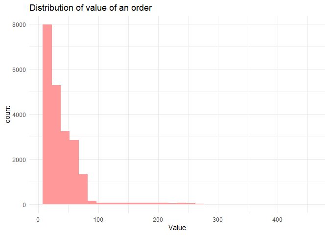

```r
by_order_df %>% ggplot(aes(x = total_price)) + geom_histogram(fill = "#FF9999") +
  labs(title = "Distribution of value of an order", x = "Value") +
  theme_minimal()
```

## 6.2. Phân tích nhu cầu tiêu thụ pizza theo thời gian

Biểu đồ nhu cầu tiêu thụ pizza theo giờ

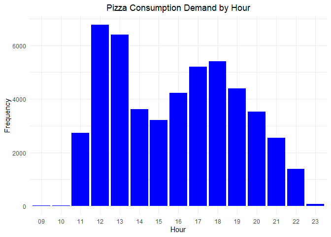

```r
ggplot(data = df, aes(x = order_hour, y = quantity)) +
  geom_col(fill = "blue") +
  theme_minimal() +
  labs(x = "Hour", y = "Frequency", title = "Pizza Consumption Demand by Hour") +
  theme(plot.title = element_text(hjust = 0.5)
  )
```

- Biểu đồ cho thấy sự phân bố số lượng đơn đặt hàng theo từng giờ trong ngày.
- Giờ có lượng đơn hàng cao nhất là từ 12h đến 13h trưa. Thời gian từ 17h đến 18h cũng có lượng đơn hàng khá cao. Hai khoảng giờ cao điểm này có thể là các thời điểm mà người tiêu dùng có nhiều thời gian rảnh sau giờ làm việc cho bữa ăn trưa và ăn tối. Các khung giờ khác có số lượng đơn hàng giảm dần và thấp nhất là vào khoảng 9h,10h sáng và 23h khuya.

> Dựa vào biểu đồ này, ta có thể quan sát rõ hành vi của người tiêu dùng. Giờ trưa và giờ tan làm có thể là lúc người tiêu dùng có thời gian và nhu cầu đặt thức ăn nhiều hơn. Điều này giúp nhà hàng lập kế hoạch hỗ trợ và chiến lược quảng cáo tốt hơn để thu hút và giữ chân khách hàng.

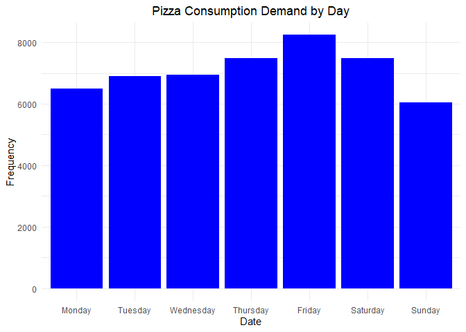

```r
ggplot(data = df, aes(x = order_weekday, y = quantity)) +
  geom_col(fill = "blue") +
  theme_minimal() +
  labs(x = "Date", y = "Frequency", title = "Pizza Consumption Demand by Day") +
  theme(plot.title = element_text(hjust = 0.5)
  )
```

- Thứ Sáu có nhu cầu cao nhất. Điều này cho thấy mọi người có xu hướng đặt pizza nhiều hơn khi cuối tuần đến gần. Còn lại các ngày khác trong tuần, từ Thứ Hai đến Thứ Năm, nhu cầu tương đối ổn định cho thấy sự tiêu thụ pizza đều đặn trong suốt các ngày làm việc.Nhu cầu thấp nhất vào Chủ Nhật, có khả năng cao khách hàng chuẩn bị cho tuần làm việc sắp tới.

> Biểu đồ cho thấy nhu cầu tiêu thụ pizza tăng cao vào cuối tuần, đạt đỉnh vào Thứ Sáu, có thể do các buổi tụ họp xã hội hoặc xu hướng ăn uống ngoài khi bắt đầu cuối tuần.

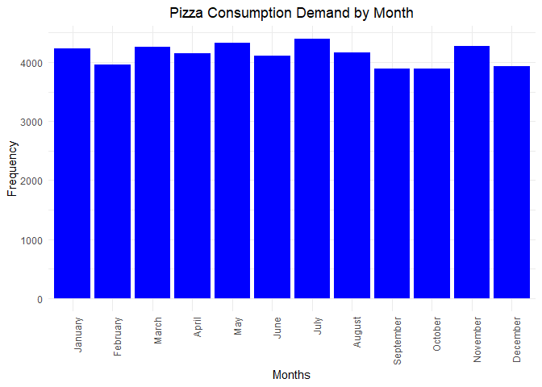

```r
ggplot(data = df, aes(x = order_month, y = quantity)) +
  geom_col(fill = "blue") +
  theme_minimal() +
  labs(x = "Months", y = "Frequency", title = "Pizza Consumption Demand by Month") +
  theme(axis.text.x = element_text(angle = 90, hjust = 1) ,
        plot.title = element_text(hjust = 0.5))
```

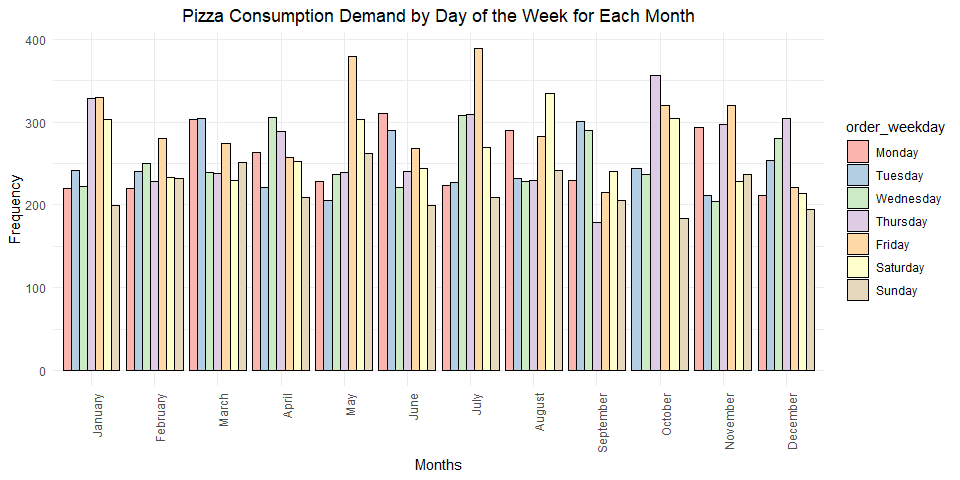

```r
ggplot(by_order_df, aes(x = order_month, fill = order_weekday)) +
  geom_bar(position = "dodge", color = "black") +
  scale_fill_brewer(palette = "Pastel1") +
  theme_minimal() +
  labs(x = "Months", y = "Frequency", title = "Pizza Consumption Demand by Day of the Week for Each Month") +
  theme(axis.text.x = element_text(angle = 90, hjust = 1) ,
        plot.title = element_text(hjust = 0.5))
```

> Ta có thể kết luận rằng nhu cầu tiêu thụ pizza thay đổi theo cả tháng và ngày trong tuần, với xu hướng tiêu thụ cao vào các ngày bắt đầu cuối tuần và một số tháng cụ thể có kì nghỉ lễ hoặc thời tiết đẹp. Điều này có thể được sử dụng để dự đoán nhu cầu và tối ưu hóa nguồn cung cho các khoảng thời gian cao điểm trong năm.

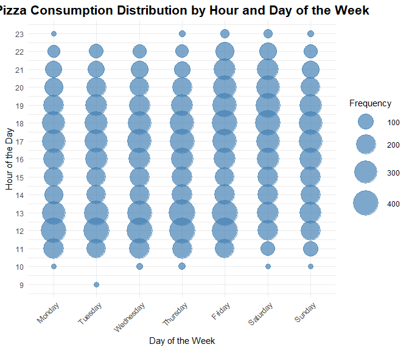

```r
by_order_df$order_hour <- as.numeric(by_order_df$order_hour)

order_by_hour <- by_order_df %>%
  group_by(order_weekday, order_hour) %>%
  summarise(frequency = n(), .groups = "drop")

ggplot(data = order_by_hour, aes(x = order_weekday, y = order_hour, size = frequency)) +
  geom_point(color = "steelblue", alpha = 0.7) +
  scale_size(range = c(3, 15), name = "Frequency") +
  theme_minimal() +
  labs(
    x = "Day of the Week",
    y = "Hour of the Day",
    title = "Pizza Consumption Distribution by Hour and Day of the Week"
  ) +
  theme(
    plot.title = element_text(hjust = 0.5, size = 16, face = "bold"),
    axis.text.x = element_text(angle = 45, hjust = 1)
  ) +
  scale_y_continuous(
    breaks = seq(9, 23, by = 1),
    expand = expansion(mult = c(0.05, 0.05))
  )
```

Các đơn đặt hàng chủ yếu được đặt từ trưa (11 giờ) đến tối (22 giờ), biểu hiện khoảng thời gian từ trưa đến tối là thời gian cao điểm cho nhu cầu tiêu thụ pizza, đặc biệt vào Thứ Sáu và Thứ Bảy. Ngoài khung giờ này là các điểm dữ liệu ngoài (outliers) cho các đơn hàng vào sáng sớm hoặc đêm muộn. Điều này cho thấy có một số ít đơn đặt hàng trong khoảng thời gian ngoài giờ cao điểm.

> Có thể thấy ít có sự biến động giữa các ngày trong tuần và xu hướng chung là tiêu thụ pizza ổn định từ buổi trưa đến tối. Không có ngày nào có sự biến động lớn hoặc bất thường. Nhu cầu khá ổn định trong cả tuần nhưng có xu hướng cao hơn vào Thứ Sáu và Thứ Bảy

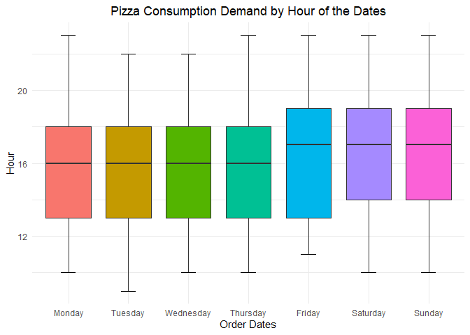

```r
ggplot(data = by_order_df, aes(x = order_weekday, y = order_hour, fill = order_weekday)) +
  stat_boxplot(geom = "errorbar", width = 0.25) +
  geom_boxplot(outlier.color = "red", outlier.shape = 16, outlier.size = 2) +
  theme_minimal() +
  labs(x = "Order Dates", y = "Hour", title = "Pizza Consumption Demand by Hour of the Dates") +
  theme(
    legend.position = "none",
    plot.title = element_text(hjust = 0.5)
  )
```

Biểu đồ hộp (boxplot) thể hiện sự phân phối thời gian trong ngày mà pizza được tiêu thụ, được chia theo từng ngày trong tuần. Phân phối phổ biến của thời gian đặt hàng là từ 13h đến 19h tối. Thời gian trung bình đặt hàng các ngày trong tuần là 16h và các ngày cuối tuần (Friday, Saturday, Sunday) có trung vị cao hơn là 17h. Điều này có thể phản ánh vào cuối tuần nhu cầu cao hơn vào buổi tối hoặc các khung giờ muộn. Đặc biệt là Friday, có độ rộng của box lớn nhất, hay mức độ phân tán rộng hơn các ngày khác thể hiện rằng khách hàng đặt pizza vào cả những khung giờ không phổ biến (ngoài giờ cao điểm).

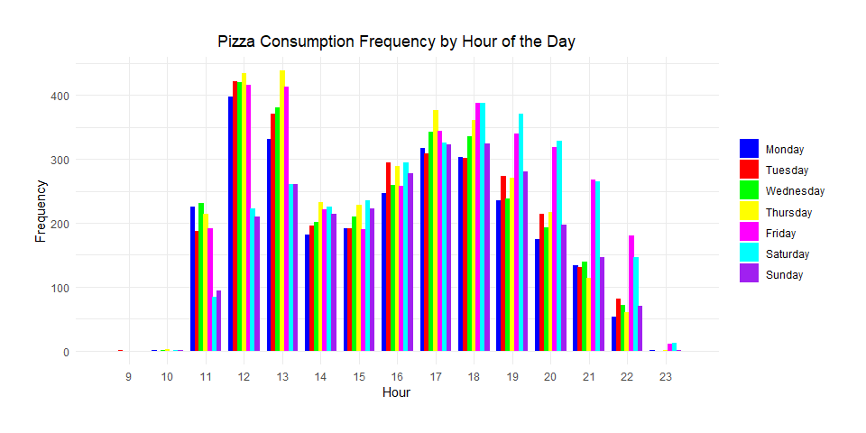

```r
df_table <- table(by_order_df$order_hour, by_order_df$order_weekday)
df_freq <- as.data.frame(df_table)
colnames(df_freq) <- c("Hour", "Day", "Frequency")


ggplot(df_freq, aes(x = Hour, y = Frequency, fill = Day)) +
  geom_bar(stat = "identity", position = position_dodge(width = 0.8))  +
  scale_fill_manual(values = c("blue", "red", "green", "yellow", "magenta", "cyan", "purple", "orange")) +
  theme_minimal() +
  labs(title = "Pizza Consumption Frequency by Hour of the Day", x = "Hour", y = "Frequency") +
  theme(
    plot.title = element_text(hjust = 0.5),
    legend.title = element_blank()
  ) +
  theme(legend.position = "right") +
  theme(plot.margin = unit(c(1,1,1,1), "cm")) +
  scale_x_discrete(expand = expansion(mult = c(0.1, 0.1)))
```

## 6.3. Phân tích nguyên liệu:

### 6.3.1. Phân tích tần suất xuất hiện các từ trong nguyên liệu làm pizza

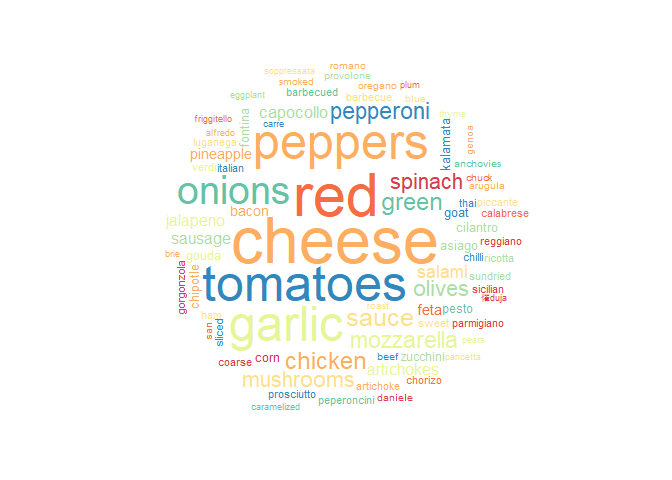

```r
text <- paste(df$pizza_ingredients, collapse = " ")

set.seed(1234)
wordcloud(words = text,
          scale = c(4, 0.5),
          max.words = 121,
          random.order = FALSE,
          colors = brewer.pal(8, "Spectral"),
          random.color = TRUE)
```

- Từ có tần suất lớn nhất là “cheese”, một thành phần quan trọng và phổ biến nhất trong pizza. Bên cạnh đó còn có các từ như “garlic”, “tomatoes”, “peppers”,..đây cũng là những nguyên liệu phổ biến. Điều này phù hợp với đặc trưng của món pizza.
- Ngoài ra, một số nguyên liệu ít phổ biến với kích thước từ nhỏ và các loại phô mai đặc biệt (gouda, ricotta) có thể phù hợp với những khách hàng thích hương vị độc đáo nên tần suất rất ít.

### 6.3.2. Phân tích top 10 nguyên liệu sử dụng nhiều nhất trong pizza theo tháng

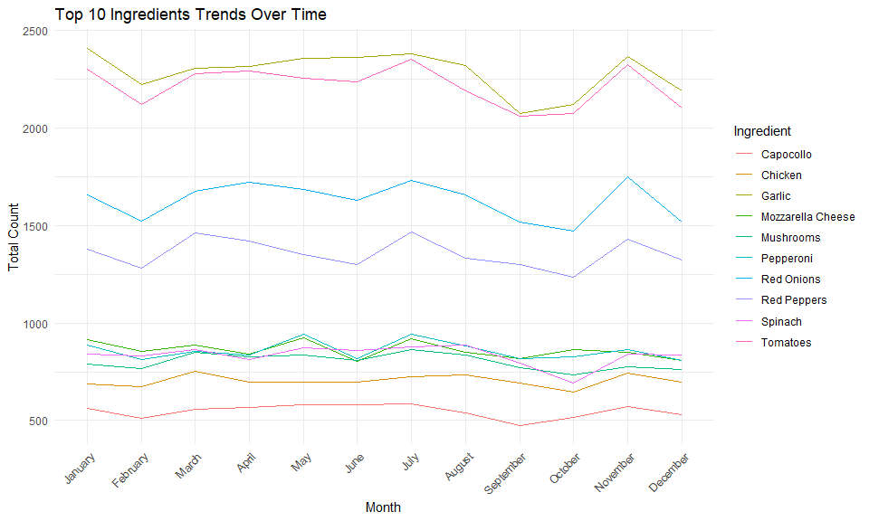

```r
ingredient_list <- df %>%
  mutate(ingredients = str_split(pizza_ingredients, ", ")) %>%
  unnest(ingredients)

ingredient_matrix <- ingredient_list %>%
  count(order_month, ingredients) %>%
  pivot_wider(names_from = ingredients, values_from = n, values_fill = 0)

ingredient_trends <- ingredient_matrix %>%
  pivot_longer(cols = -order_month, names_to = "ingredient", values_to = "count") %>%
  group_by(order_month, ingredient) %>%
  summarise(total_count = sum(count), .groups = "drop")

top_ingredients <- ingredient_trends %>%
  group_by(ingredient) %>%
  summarise(total_count = sum(total_count)) %>%
  top_n(10, total_count) %>%
  pull(ingredient)

filtered_trends <- ingredient_trends %>%
  filter(ingredient %in% top_ingredients)

ggplot(filtered_trends, aes(x = order_month, y = total_count, color = ingredient, group = ingredient)) +
  geom_line() +
  theme_minimal() +
  labs(
    title = "Top 10 Ingredients Trends Over Time",
    x = "Month",
    y = "Total Count",
    color = "Ingredient"
  ) +
  theme(axis.text.x = element_text(angle = 45, hjust = 1))
```

> Nhà hàng có thể dựa vào phân tích để cân nhắc quản lý kho nguyên liệu phù hợp, đặc biệt là các thành phần phổ biến trong các món đặc trưng. Đồng thời, có thể thử nghiệm các loại pizza mới với các nguyên liệu ít phổ biến hơn để thu hút khách hàng thích trải nghiệm hương vị mới.

## 6.4. Phân tích doanh số:

### 6.4.1. Phân tích doanh số theo kích cỡ bánh

- Tổng hợp dữ liệu tính doanh số mỗi tháng của từng loại pizza

```r
sales_by_size <- df %>%
  group_by(pizza_size, order_month) %>%
  summarise(
    total_sales = sum(quantity)
  )
head(sales_by_size)
```

```
## # A tibble: 6 x 3
## # Groups:   pizza_size [1]
##   pizza_size order_month total_sales
##   <fct>      <fct>             <dbl>
## 1 S          January            1229
## 2 S          February           1189
## 3 S          March              1253
## 4 S          April              1151
## 5 S          May                1265
## 6 S          June               1131
```

- Trực quan hóa bảng số liệu trên bằng biểu đồ tròn

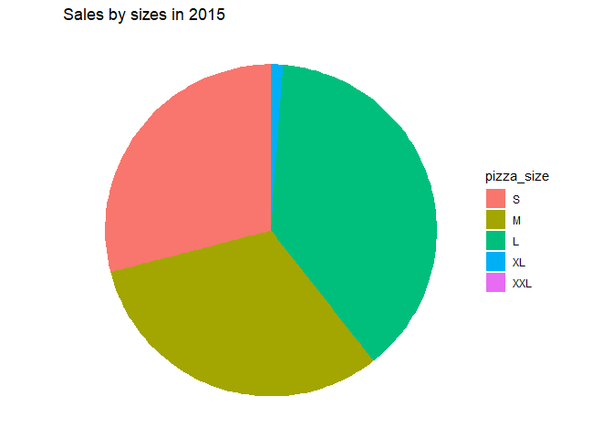

```r
ggplot(sales_by_size, aes(x = "", y = total_sales, fill = pizza_size)) +
  geom_bar(stat = "identity") +
  coord_polar(theta = "y") +
  labs(title = "Sales by sizes in 2015") +
  theme_void()
```

Bánh pizza cỡ L bán chạy nhất với 18956 chiếc bánh chiếm 38% doanh số, theo sau là cỡ M với 15635 bánh (32%) và cỡ S với 14403 bánh (29%). Bánh size XL và XXL có doanh số rất thấp, cả hai chỉ chiếm chưa tới 2% tổng doanh số của năm 2015.

### 6.4.2. Phân tích doanh số theo danh mục bánh

- Tổng hợp dữ liệu theo danh mục bánh

```r
sales_by_category <- df %>%
  group_by(pizza_category, order_month) %>%
  summarise(
    total_sales = sum(quantity)
  )
sales_by_category
```

```
## # A tibble: 48 x 3
## # Groups:   pizza_category [4]
##    pizza_category order_month total_sales
##    <fct>          <fct>             <dbl>
##  1 Chicken        January             913
##  2 Chicken        February            875
##  3 Chicken        March               994
##  4 Chicken        April               924
##  5 Chicken        May                 939
##  6 Chicken        June                910
##  7 Chicken        July                963
##  8 Chicken        August              934
##  9 Chicken        September           900
## 10 Chicken        October             832
## # i 38 more rows
```

- Trực quan hóa

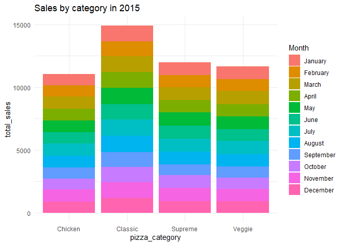

```r
ggplot(sales_by_category, aes(x = pizza_category, y = total_sales, fill = order_month)) +
  geom_col() +
  labs(title = "Sales by category in 2015",
       fill = "Month") +
  theme_minimal()
```

Danh mục bánh Classic bánh chạy nhất với 14888 chiếc. Ba loại còn lại có sự chênh lệch không đáng kể với nhau, cụ thể Supreme là 11987, Veggie là 11649 và thấp nhất là Chicken với 11050 chiếc bánh.  
Đối với từng danh mục pizza, doanh số không có sự chênh lệch nào đáng kể giữa các tháng.

#### Kiểm tra sự chênh lệch trong doanh số giữa các danh mục pizza có ý nghĩa thống kê không bằng One-way ANOVA

One-Way ANOVA (One-Way Analysis of Variance) là một phương pháp kiểm định thống kê được sử dụng để so sánh trung bình của nhiều nhóm dựa trên một đặc trưng. Phương pháp kiểm định này so sánh phương sai giữa các nhóm với phương sai trong từng nhóm thông qua F-statistic.

```r
anova_result <- aov(total_sales ~ pizza_category, data = sales_by_category)
summary(anova_result)
```

```
##                Df Sum Sq Mean Sq F value Pr(>F)
## pizza_category  3 728920  242973   90.09 <2e-16 ***
## Residuals      44 118669    2697
## ---
## Signif. codes:  0 '***' 0.001 '**' 0.01 '*' 0.05 '.' 0.1 ' ' 1
```

Kết quả có p-value (Pr(>F)) < 2e-16, gần bằng 0 nên ta có đủ bằng chứng để *bác bỏ giả thuyết không*. Bên cạnh đó, F value bằng 90, giá trị cao này cho thấy rằng sự khác biệt doanh số giữa các danh mục pizza lớn hơn nhiều so với sự biến động giữa các tháng của từng danh mục. Vì vậy, sự chênh lệch trong doanh số giữa các danh mục pizza là đáng kể hay nói cách khác là danh mục có tác động đến doanh số.

### 6.4.3. Phân tích doanh số bán hàng của từng bánh pizza

#### Doanh số của từng bánh pizza trong cả năm 2015

- Số bánh pizza cửa hàng kinh doanh

```r
sales_by_pizza <- df %>%
  group_by(pizza_name) %>%
  summarise(total_sales = sum(quantity))

print(length(sales_by_pizza$pizza_name))
```

```
## [1] 32
```

Cửa hàng kinh doanh 32 bánh pizza khác nhau.

- Trực quan hóa doanh số của từng bánh pizza trong một năm

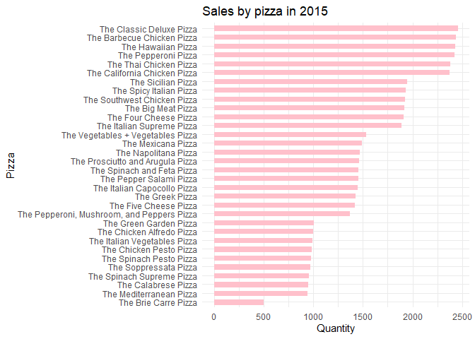

```r
sales_by_pizza %>%
  ggplot(aes(x = total_sales, y = reorder(pizza_name, total_sales))) +
  geom_col(color = "pink", fill = "pink", width = 0.5) +
  labs(title = "Sales by pizza in 2015",
       x = "Quantity",
       y = "Pizza") +
  theme_minimal()
```

Pizza bán chạy nhất là The Classic Deluxe Pizza với 2453 bánh.  
Pizza bán chậm nhất là The Brie Carre Pizza với 490 bánh. Ta có thể dễ dàng nhận thấy sự chênh lệch rất lớn giữa doanh số của nó với các bánh khác, trong đó, chỉ bằng khoảng 50% doanh số của pizza bán chậm thứ hai (The Mediterranean Pizza) và bằng khoảng 20% doanh số của bánh bán chạy nhất.

##### Xem các thuộc tính của ba bánh này để dự đoán nguyên nhân gây ra sự chênh lệch lớn

```r
df %>% select(pizza_name, pizza_size, unit_price, pizza_category, pizza_ingredients) %>%
  group_by(pizza_name) %>% filter(pizza_name == 'The Classic Deluxe Pizza' | pizza_name == 'The Brie Carre Pizza' | pizza_name == 'The Mediterranean Pizza') %>% unique()
```

```
## # A tibble: 7 x 5
## # Groups:   pizza_name [3]
##   pizza_name              pizza_size unit_price pizza_category pizza_ingredients
##   <chr>                   <fct>           <dbl> <fct>          <chr>
## 1 The Classic Deluxe Piz~ M                16   Classic        Pepperoni, Mushr~
## 2 The Classic Deluxe Piz~ S                12   Classic        Pepperoni, Mushr~
## 3 The Mediterranean Pizza M                16   Veggie         Spinach, Articho~
## 4 The Classic Deluxe Piz~ L                20.5 Classic        Pepperoni, Mushr~
## 5 The Mediterranean Pizza L                20.2 Veggie         Spinach, Articho~
## 6 The Mediterranean Pizza S                12   Veggie         Spinach, Articho~
## 7 The Brie Carre Pizza    S                23.6 Supreme        Brie Carre Chees~
```

- Có thể nhận thấy sự chênh lệch rất lớn, gần gấp đôi trong giá của The Brie Carre Pizza size S (23.65 USD) và The Classic Deluxe Pizza hay The Mediterranean Pizza size S (12 USD). Do đó em cho rằng *biến unit_price và pizza_size có ảnh hưởng tới doanh số, hơn thế nữa hai biến này là hai biến tương tác*.
- Bên cạnh đó, sự khác biệt trong doanh số giữa The Classic Deluxe Pizza và The Mediterranean Pizza mặc dù chúng có mức giá gần như giống hệt nhau cho các kích cỡ. Điều này cho thấy *biến pizza_category cũng ảnh hưởng tới doanh số*. Biến pizza_ingredients sẽ trực tiếp phản ánh tới pizza_cateogry nên em bỏ qua nó.
- Ngoài ra, The Brie Carre Pizza chỉ có một kích cỡ trong khi đa số bánh còn lại có nhiều kích cỡ, em nghi ngờ độ đa dạng của một bánh pizza ảnh hưởng tới doanh số của nó. Trực quan hóa để kiểm tra:

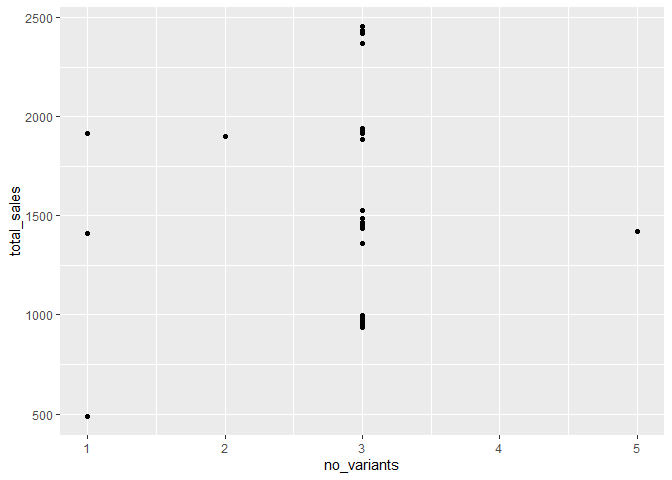

```r
df %>% select(pizza_name, pizza_size) %>% unique() %>%
  group_by(pizza_name) %>% summarise(no_variants = n()) %>%
  merge(sales_by_pizza) %>% ggplot(aes(x = no_variants, y = total_sales)) + geom_point()
```

> Không có mối quan hệ tương quan giữa no_variants và total_sales, nghĩa là độ đa dạng của một bánh pizza không ảnh hưởng tới doanh số của nó.

#### Doanh số của từng bánh pizza trong mỗi tháng

```r
sales_by_pizza_monthly <- df %>%
  group_by(pizza_name, order_month) %>%
  summarise(total_sales = sum(quantity))
```

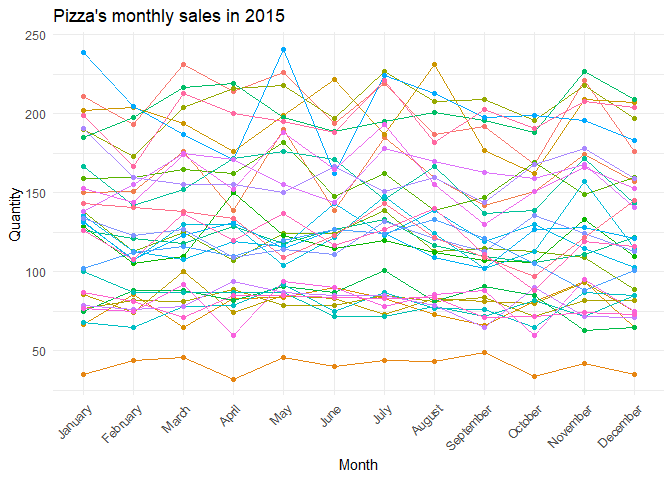

```r
ggplot(sales_by_pizza_monthly, aes(x = order_month, y = total_sales, color = pizza_name, group = pizza_name)) +
  geom_line() +
  geom_point() +
  labs(title = "Pizza's monthly sales in 2015",
       x = "Month",
       y = "Quantity",
       color = "Pizza Name") +
  theme_minimal() +
  theme(axis.text.x = element_text(angle = 45, hjust = 1)) +
  guides(color = "none")
```

Mỗi đường trên biểu đồ thể hiện sự biến động trong doanh số giữa các tháng của một pizza. Có một số bánh có sự biến động trong doanh số một cách đáng chú ý.

##### Kiểm định doanh số của từng pizza có khác biệt đáng kể giữa các tháng hay không bằng Kruskal-Wallis

Kiểm định Kruskal-Wallis là một phương pháp thống kê phi tham số dùng để so sánh ba nhóm dữ liệu trở lên nhằm xác định xem có sự khác biệt đáng kể nào giữa các nhóm này hay không. Đây là một lựa chọn thay thế cho phân tích phương sai một chiều (ANOVA) khi dữ liệu không tuân theo phân phối chuẩn, phù hợp để kiểm tra sự biến động doanh số của một pizza qua các tháng có ý nghĩa hay không.  
Trong sales_by_pizza_monthly, mỗi pizza chỉ có một quan sát cho một tháng nên kiểm định Kruskal-Wallis sẽ không có đủ thông tin để so sánh và phát hiện sự khác biệt có ý nghĩa. Do đó em sẽ tổng hợp doanh số của từng pizza theo ngày rồi thực hiện kiểm định cho từng pizza

```r
sales_by_pizza_daily <- df %>% group_by(pizza_name, order_date, order_month) %>% summarise(sales = sum(quantity), .groups = 'drop')

kruskal_test <- sales_by_pizza_daily %>%
  group_by(pizza_name) %>%
  summarize(p_value = kruskal.test(sales ~ order_month)$p.value)

print(kruskal_test)
```

```
## # A tibble: 32 x 2
##    pizza_name                   p_value
##    <chr>                          <dbl>
##  1 The Barbecue Chicken Pizza     0.336
##  2 The Big Meat Pizza             0.379
##  3 The Brie Carre Pizza           0.214
##  4 The Calabrese Pizza            0.219
##  5 The California Chicken Pizza   0.322
##  6 The Chicken Alfredo Pizza      0.437
##  7 The Chicken Pesto Pizza        0.795
##  8 The Classic Deluxe Pizza       0.629
##  9 The Five Cheese Pizza          0.126
## 10 The Four Cheese Pizza          0.318
## # i 22 more rows
```

Kết quả không có p-value nào có giá trị nhỏ hơn 0.01, nên ta chấp nhận giả thuyết không và kết luận rằng không có sự khác biệt đáng kể trong doanh số giữa các tháng đối với mỗi pizza, hay nói cách khác, doanh số của mỗi pizza tương đối ổn định giữa các tháng trong năm 2015.

## 6.5. Phân tích doanh thu theo thời gian:

### 6.5.1. Phân tích doanh thu theo giờ trong ngày của một tuần

```r
# Tính toán doanh thu theo giờ trong ngày của một tuần:
revenue_by_hour_day <- df %>%
  group_by(order_hour, order_weekday) %>%
  summarise(revenue = sum(total_price))
print(revenue_by_hour_day)
```

```
## # A tibble: 95 x 3
## # Groups:   order_hour [15]
##    order_hour order_weekday revenue
##    <chr>      <fct>           <dbl>
##  1 09         Tuesday          83
##  2 10         Monday           50.2
##  3 10         Wednesday        76.6
##  4 10         Thursday         86.5
##  5 10         Saturday         52.8
##  6 10         Sunday           37.5
##  7 11         Monday         7767
##  8 11         Tuesday        7147.
##  9 11         Wednesday      8686.
## 10 11         Thursday       7732.
## # i 85 more rows
```

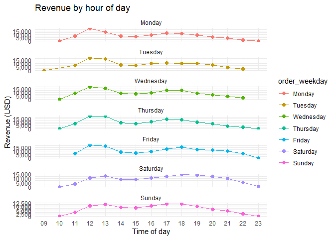

```r
# Biểu đồ đường hiển thị doanh thu theo giờ trong ngày của một tuần:
ggplot(revenue_by_hour_day, aes(x = order_hour, y = revenue, fill=order_weekday, color=order_weekday, group = order_weekday)) +
  geom_line()+
  geom_point(size = 2) +
  facet_wrap(~order_weekday, nrow = 7, scales = "free_y")+
  theme_minimal() +
  labs(
    title = "Revenue by hour of day",
    x = "Time of day",
    y = "Revenue (USD)",
  ) +
  scale_y_continuous(labels = scales::comma)
```

> Biểu đồ cho thấy doanh thu đều chạm đỉnh vào 12h các ngày trong tuần, trừ Thứ 7 và Chủ Nhật. Điều này cho thấy doanh thu sẽ cao vào giờ nghỉ trưa của những ngày đi làm của khách hàng. Ngày Thứ 7 và Chủ Nhật, doanh thu sẽ cao hơn vào thời điểm sau 17h đến 20h. Điều này có thể do khách hàng có xu hướng ăn tối muộn hơn vào cuối tuần. Bên cạnh đó, có sự chênh lệch doanh thu đáng kể vào các thời điểm trong ngày. Cửa hàng có thể triển khai các chương trình khuyến mãi vào các khung giờ thấp điểm để thu hút thêm khách hàng và tăng doanh thu.

### 6.5.2. Phân tích doanh thu một ngày dùng Time Series - Chuỗi thời gian

- Khái niệm về chuỗi thời gian:

Chuỗi thời gian là tập hợp các dữ liệu có sự phụ thuộc của các giá trị quan sát được thu thập qua thời gian. Với mục tiêu là dùng các dữ liệu trong quá khứ để phân tích và dự báo cho dữ liệu trong tương lai.

- Các thành phần chuỗi thời gian:
1. Thành phần xu hướng (Trend): Thành phần xu hướng là thành phần thể hiện mức tăng giảm của lượng biến quan sát theo một quy luật nào đó trong một khoảng thời gian đủ dài.
2. Thành phần chu kỳ (Cyclic): Các mẫu chu kỳ xuất hiện dưới dạng những dao động không đều trong dữ liệu, bị ảnh hưởng bởi các điều kiện kinh tế và thường liên quan đến chu kỳ kinh doanh rộng lớn hơn. Khác với tính mùa vụ, ảnh hưởng chu kỳ đối với chuỗi thời gian trong tương lai là không thể đoán trước.
3. Thành phần mùa (Seasonal): Trong khi thành phần xu hướng và thành phần chu kỳ của chuỗi thời gian được xác định bằng cách phân tích chuỗi thời gian kéo dài qua nhiều năm, thì nhiều chuỗi thời gian cho thấy có những kiểu biến thiên lặp lại theo tần suất theo quý , theo mùa,…, biến động của lượng biến tuân theo một quy luật nào đó giữa các thời điểm trong năm và lặp lại trong các năm kế tiếp.
4. Thành phần bất thường: Ngoài các yếu tố xu hướng , chu kỳ, và mùa, thực tế giá trị lượng biến quan sát còn chịu sự chi phối của các yếu tố ngẫu nhiên, các yếu tố bất thường ngắn hạn không chịu sự liên kết với thành phần khác như mùa, chu kỳ, xu thế.
- Phân biệt giữa các mẫu chu kỳ và mùa vụ: Các dao động không có tần suất cố định là chu kỳ. Nếu các dao động khớp với các khoảng thời gian theo lịch, chúng là mùa vụ.
- Đồ thị thời gian: Đồ thị thời gian là những đồ thị biểu diễn các quan sát được vẽ theo các mốc thời gian tương ứng, với các điểm dữ liệu liên tiếp được nối bằng các đoạn thẳng.
- Ứng dụng trong việc phân tích doanh thu một ngày với chuỗi thời gian: dùng chuỗi thời gian do doanh thu pizza tính theo ngày có nhiều điểm dữ liệu với các mốc thời gian theo ngày.
- Sao chép dữ liệu vào biến df_ts để xử lý trên bản sao không gây ảnh hưởng đến dữ liệu gốc.

```r
df_ts <- df
```

- Chuyển đổi cột order_date thành kiểu Date

```r
df_ts$order_date <- as.Date(df_ts$order_date, format = "%Y-%m-%d")
```

- Tính toán doanh thu theo ngày của một năm:

```r
revenue_by_date <- df_ts %>%
  group_by(order_date) %>%
  summarise(revenue = sum(total_price))
revenue_by_date
```

```
## # A tibble: 358 x 2
##    order_date revenue
##    <date>       <dbl>
##  1 2015-01-01   2714.
##  2 2015-01-02   2732.
##  3 2015-01-03   2662.
##  4 2015-01-04   1755.
##  5 2015-01-05   2066.
##  6 2015-01-06   2429.
##  7 2015-01-07   2202.
##  8 2015-01-08   2838.
##  9 2015-01-09   2127.
## 10 2015-01-10   2464.
## # i 348 more rows
```

- Tạo chuỗi thời gian (time series) với tần suất 365 ngày (Năm 2015 không phải năm nhuận)

```r
revenue_ts_date<-ts(revenue_by_date$revenue, start = c(2015, 1), frequency = 365)
# Kiểm tra chuỗi thời gian
print(revenue_ts_date)
```

```
## Time Series:
## Start = c(2015, 1)
## End = c(2015, 358)
## Frequency = 365
##   [1] 2713.85 2731.90 2662.40 1755.45 2065.95 2428.95 2202.20 2838.35 2127.35
##  [10] 2463.95 1872.30 1919.05 2049.60 2527.40 1984.80 2594.15 2064.10 1976.85
##  [19] 2387.15 2397.90 2040.55 2496.70 2423.70 2289.25 1617.55 1884.40 2528.05
##  [28] 2016.00 2045.30 2270.30 2417.85 3189.20 2328.60 2614.80 2233.90 2215.80
##  [37] 2509.95 2237.65 2035.00 2195.35 2056.50 2460.00 2158.80 2754.50 2319.15
##  [46] 2141.25 1968.80 2121.90 2642.85 2030.25 2891.15 2111.00 1579.95 2168.55
##  [55] 2194.55 2341.30 2261.30 2857.95 2539.60 1598.55 2379.05 2287.90 2444.30
##  [64] 2350.65 2513.95 2400.45 2188.15 2334.55 2388.70 2207.70 1994.90 2786.65
##  [73] 2039.45 2068.60 2295.05 2965.30 2075.40 2388.60 2461.25 2267.40 1259.25
##  [82] 2232.55 2162.30 1927.75 2215.50 2744.80 2252.10 2154.25 2255.45 2756.60
##  [91] 2176.85 2547.15 2538.20 2767.55 1909.85 2622.35 2234.25 2293.95 2047.30
```

[output cut: 29 more lines]

- Trực quan hóa doanh thu theo ngày với time_series do có nhiều điểm dữ liệu:

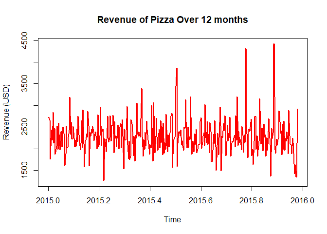

```r
plot(revenue_ts_date, main = "Revenue of Pizza Over 12 months", xlab = "Time", ylab = "Revenue (USD)", col = "red", lwd = 2)
```

Thời gian cần thiết:  
Tối thiểu một chu kỳ hoàn chỉnh để xác định mùa vụ. Tối thiểu hai chu kỳ để xác nhận tính lặp lại và phân tích chính xác hơn.  
Ví dụ:  
Chu kỳ hàng tuần (7 ngày): Cần ít nhất 7-14 ngày.  
Chu kỳ hàng tháng (12 tháng): Cần ít nhất 12-24 tháng.  
Chu kỳ hàng năm (365 ngày): Cần ít nhất 365-730 ngày (1-2 năm).

> Do dữ liệu chỉ các ngày trong một năm 2015 nên chuỗi thời gian revenue_ts_date không có tính mùa vụ.

### 6.5.3. Phân tích doanh thu theo tháng

```r
revenue_by_month <- df %>%
  group_by(order_month) %>%
  summarise(revenue = sum(total_price))
revenue_by_month
```

```
## # A tibble: 12 x 2
##    order_month revenue
##    <fct>         <dbl>
##  1 January      69793.
##  2 February     65160.
##  3 March        70397.
##  4 April        68737.
##  5 May          71403.
##  6 June         68230.
##  7 July         72558.
##  8 August       68278.
##  9 September    64180.
## 10 October      64028.
## 11 November     70395.
## 12 December     64701.
```

- Trực quan hóa bằng biểu đồ cột để so sánh doanh thu giữa các tháng trong năm:

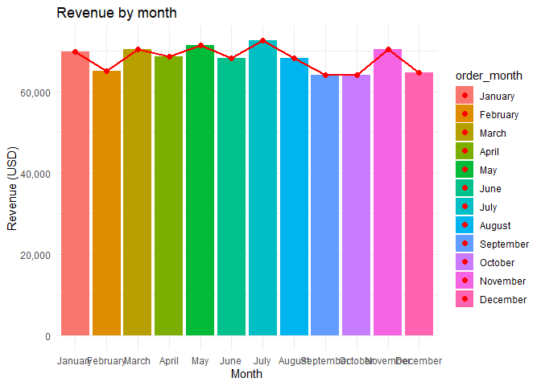

```r
ggplot(revenue_by_month, aes(x = order_month, y = revenue, group = 1, fill = order_month)) +
  geom_bar(stat = "identity") +
  geom_line(aes(group = 1), color = "red", size = 1) +
  geom_point(color = "red", size = 2) +
  theme_minimal() +
  labs(
    title = "Revenue by month",
    x = "Month",
    y = "Revenue (USD)"
  ) +
  scale_y_continuous(labels = scales::comma)
```

# Phần 7. Dự đoán doanh số theo sản phẩm:

Mục tiêu của phần này là xây dựng mô hình dự đoán doanh số trong một tháng của một bánh pizza cụ thể, tức là dự đoán xem cửa hàng bán được bao nhiêu bánh pizza đó bằng các đặc trưng của nó cùng với dữ liệu bán hàng trong quá khứ. Em lựa chọn sử dụng hai mô hình là Linear Regression và Random Forest nhằm tận dụng những ưu điểm riêng của mỗi phương pháp và đánh giá hiệu quả của chúng trong bối cảnh dữ liệu hiện có.

- Tổng hợp dữ liệu chứa doanh số mỗi tháng của từng bánh pizza

```r
sales_data <- df %>%  group_by(pizza_name, unit_price, pizza_size, pizza_category, order_month) %>% summarise(sales = sum(quantity))
```

[output not shown]

```r
dim(sales_data)
```

```
## [1] 1091    6
```

```r
summary(sales_data)
```

```
##   pizza_name          unit_price    pizza_size pizza_category   order_month
##  Length:1091        Min.   : 9.75   S  :360    Chicken:216    January : 91
##  Class :character   1st Qu.:12.50   M  :348    Classic:287    February: 91
##  Mode  :character   Median :16.50   L  :360    Supreme:300    March   : 91
##                     Mean   :16.49   XL : 12    Veggie :288    April   : 91
##                     3rd Qu.:20.25   XXL: 11                   May     : 91
##                     Max.   :35.95                             June    : 91
##                                                               (Other) :545
##      sales
##  Min.   :  1.00
##  1st Qu.: 27.00
##  Median : 39.00
##  Mean   : 45.44
##  3rd Qu.: 59.00
##  Max.   :190.00
##
```

Dữ liệu gồm 1091 quan sát, mỗi quan sát thể hiện doanh số của một bánh với kích cỡ xác định (hoặc S hoặc M hoặc L hoặc XL hoặc XXL), đơn giá tương ứng, thuộc danh mục nào và doanh số trong một tháng cụ thể là bao nhiêu.

- Trực quan hóa mối quan hệ giữa doanh số và giá cùng với kích cỡ và danh mục bánh.

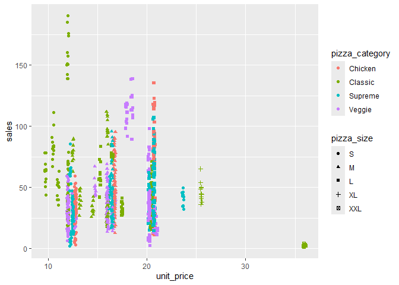

```r
sales_data %>%
  ggplot(aes(x = unit_price, y = sales, shape = pizza_size, color = pizza_category)) +
  geom_jitter()
```

Biểu đồ cho thấy tác động của giá bán lên sales khác nhau đối với các cỡ bánh khác nhau và các loại bánh khác nhau. Cụ thể như bánh size S giá thấp (~10) có doanh số cao hơn rất nhiều so với bánh size S giá trên 20 USD. Và cùng ở khoảng giá 20 USD nhưng doanh số của các danh mục chênh lệch nhau rất rõ rệt.

> Vì vậy, ngoài 4 biến độc lập đã nêu (pizza_name, unit_price, pizza_size và pizza_category) thì em sẽ thêm sự tác giữa unit_price và pizza_size, giữa unit_price và pizza_category vào mô hình dự đoán.

## 7.1. Dự đoán doanh số của sản phẩm bằng hồi quy tuyến tính

Hồi quy tuyến tính (Linear Regression) là mô hình thống kê đơn giản và dễ hiểu, dựa trên giả định về mối quan hệ tuyến tính giữa biến độc lập (biến đầu vào) và biến phụ thuộc (biến mục tiêu). Lý do em chọn mô hình này để dự đoán doanh số của sản phẩm vì nó đơn giản và dễ diễn giải, giúp em bước đầu hiểu rõ mức độ và hướng ảnh hưởng của từng biến độc lập đến doanh số sản phẩm. Hơn nữa, hồi quy tuyến tính là một mô hình nền tảng và thường được dùng như tiêu chuẩn so sánh cho các mô hình phức tạp hơn. Khi dữ liệu có dạng tuyến tính hoặc gần tuyến tính, Linear Regression cũng có khả năng mang lại kết quả dự đoán chính xác với chi phí tính toán thấp.

```r
lm_sales_model <- lm(sales ~ pizza_name + unit_price * (pizza_size + pizza_category), data = sales_data)
summary(lm_sales_model)
```

```
##
## Call:
## lm(formula = sales ~ pizza_name + unit_price * (pizza_size +
##     pizza_category), data = sales_data)
##
## Residuals:
##     Min      1Q  Median      3Q     Max
## -39.462  -9.895  -1.255   8.396  54.486
##
## Coefficients: (5 not defined because of singularities)
##                                                       Estimate Std. Error
## (Intercept)                                          -305.0848   143.4626
## pizza_nameThe Big Meat Pizza                          211.2482    20.3947
## pizza_nameThe Brie Carre Pizza                       -229.8351   114.5979
## pizza_nameThe Calabrese Pizza                          22.8068    12.6297
## pizza_nameThe California Chicken Pizza                 -1.7222     3.7739
## pizza_nameThe Chicken Alfredo Pizza                   -40.1389     3.7739
## pizza_nameThe Chicken Pesto Pizza                     -40.5278     3.7739
## pizza_nameThe Classic Deluxe Pizza                    120.0508    20.4359
## pizza_nameThe Five Cheese Pizza                       168.1118    23.8983
## pizza_nameThe Four Cheese Pizza                       137.0799    25.1293
## pizza_nameThe Greek Pizza                              75.2452    20.4359
## pizza_nameThe Green Garden Pizza                       64.0279    16.8439
## pizza_nameThe Hawaiian Pizza                          158.0252    35.8770
## pizza_nameThe Italian Capocollo Pizza                  91.8563    20.4359
## pizza_nameThe Italian Supreme Pizza                    43.3178    11.0452
## pizza_nameThe Italian Vegetables Pizza                 50.7997    12.5069
## pizza_nameThe Mediterranean Pizza                      62.2779    16.8439
## pizza_nameThe Mexicana Pizza                           77.5557    16.8439
## pizza_nameThe Napolitana Pizza                         92.5786    20.4359
## pizza_nameThe Pepper Salami Pizza                      31.1512    11.0452
## pizza_nameThe Pepperoni Pizza                         171.3556    41.6639
## pizza_nameThe Pepperoni, Mushroom, and Peppers Pizza  114.4435    30.3192
## pizza_nameThe Prosciutto and Arugula Pizza             31.4567    11.0452
## pizza_nameThe Sicilian Pizza                           50.6123    12.6297
## pizza_nameThe Soppressata Pizza                        17.6789    11.0452
## pizza_nameThe Southwest Chicken Pizza                 -14.3056     3.7739
## pizza_nameThe Spicy Italian Pizza                      44.4289    11.0452
## pizza_nameThe Spinach Pesto Pizza                      54.7554    13.8643
## pizza_nameThe Spinach Supreme Pizza                    17.3734    11.0452
```

[output cut: 57 more lines]

```
## pizza_categorySupreme                                     NA       NA
## pizza_categoryVeggie                                      NA       NA
## unit_price:pizza_sizeM                                -0.624 0.533071
## unit_price:pizza_sizeL                                -1.998 0.046008 *
## unit_price:pizza_sizeXL                                   NA       NA
## unit_price:pizza_sizeXXL                                  NA       NA
## unit_price:pizza_categoryClassic                      -6.724 2.90e-11 ***
## unit_price:pizza_categorySupreme                      -5.813 8.13e-09 ***
## unit_price:pizza_categoryVeggie                       -7.535 1.05e-13 ***
## ---
## Signif. codes:  0 '***' 0.001 '**' 0.01 '*' 0.05 '.' 0.1 ' ' 1
##
## Residual standard error: 16.01 on 1049 degrees of freedom
## Multiple R-squared:  0.6862, Adjusted R-squared:  0.6739
## F-statistic: 55.94 on 41 and 1049 DF,  p-value: < 2.2e-16
```

F-statistic gần bằng 56 với p-value < 2.2e-16, cho thấy rằng **mô hình hồi quy này có ý nghĩa thống kê**. Cụ thể về ý nghĩa thống kê của từng biến, các biến giả của pizza_category bị thiếu giá trị (NA), nhưng các biến tương tác của nó với unit_price có p-value rất thấp, chứng tỏ **đưa sự tương tác này vào mô hình là hợp lý**. Một số biến dummy của pizza_name, pizza_size có p-value lớn hơn 0.05 nhưng đa số có p-value nhỏ, chứng tỏ **các biến độc lập này có ý nghĩa trong mô hình**.  
Multiple R-squared bằng 0.6862 và Adjusted R-squared bằng 0.6739 cho thấy **mô hình giải thích khoảng 67% sự biến động của doanh số trong tập dữ liệu**. Mặc dù không quá cao, giá trị này vẫn cho thấy mô hình có thể giải thích một phần đáng kể sự biến động doanh số trong tập dữ liệu.

## 7.2. Dự đoán doanh số theo sản phẩm bằng random forest

Random Forest là một mô hình học máy có giám sát (supervised learning), bao gồm nhiều cây quyết định (decison tree), thường được dùng khi các quan hệ giữa các biến đầu vào và biến mục tiêu là phức tạp hoặc không tuyến tính. Em chọn Random Forest để so sánh với Linear Regression, vì mô hình này có khả năng xử lý và học những mối quan hệ phức tạp giữa các yếu tố ảnh hưởng đến doanh số của sản phẩm như đơn giá, kích cỡ,… mà mô hình tuyến tính không thể nắm bắt.

- Mỗi cây trong rừng được xây dựng theo các bước:
  - Tạo tập dữ liệu huấn luyện: Từ tập dữ liệu huấn luyện ban đầu (train data), thuật toán tạo ra tập dữ liệu huấn luyện mới bằng cách lấy mẫu ngẫu nhiên có hoàn lại (bootstrap sampling with replacement) trên 2/3 dữ liệu. 1/3 dữ liệu bị bỏ qua được gọi là out-of-bag samples.
  - Huấn luyện cây: Tại mỗi bước tách nhánh (node split), Random Forest không sử dụng toàn bộ các đặc trưng mà chỉ chọn ngẫu nhiên m đặc trưng (m<sub>try</sub>). Điều này giúp giảm sự phụ thuộc vào bất kỳ đặc trưng nào và tăng tính đa dạng của các cây.
- Kết quả cuối cùng của bài toán được tính bằng cách lấy trung bình kết quả của tất cả các cây trong rừng (do đây là bài toán hồi quy, đối với bài toán phân loại thì lấy đa số phiếu).

### Thực hiện xây dựng mô hình

- Chia tập dữ liệu thành 80% cho huấn luyện và 20% cho kiểm tra.

```r
set.seed(123)
train_index <- sample(nrow(sales_data), 0.8 * nrow(sales_data))
train_data <- sales_data[train_index, ]
test_data <- sales_data[-train_index, ]
```

- Xây dựng mô hình dự đoán doanh số

Trong công thức của mô hình này, em không chỉ định cụ thể sự tương tác giữa các biến độc lập như trong mô hình hồi quy tuyến tính vì random forest có khả năng tự học và nắm bắt các tương tác phức tạp giữa các biến.

```r
rf_sales_model <- randomForest(sales ~ pizza_name + unit_price + pizza_size + pizza_category, data = train_data)

rf_sales_model
```

```
##
## Call:
##  randomForest(formula = sales ~ pizza_name + unit_price + pizza_size +      pizza_category, data = train_data)
##                Type of random forest: regression
##                      Number of trees: 500
## No. of variables tried at each split: 1
##
##           Mean of squared residuals: 229.1109
##                     % Var explained: 69.99
```

Thông tin về mô hình:

> Mô hình này khá đáng tin cậy (RMSE khá thấp) nhưng khả năng dự đoán vẫn còn khá thấp.

### Tối ưu hóa mô hình

Hiện tại, số cây quyết định của mô hình là 500 và số biến được thử tại mỗi lần phân tách là 1.

- Kiểm tra ngưỡng cây tối ưu chưa:

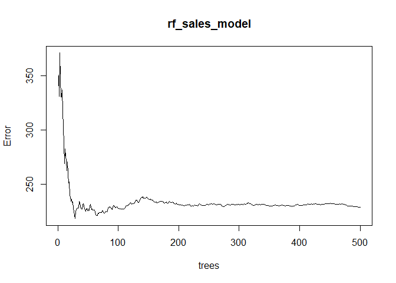

```r
plot(rf_sales_model)
```

Biểu đồ cho thấy **500 cây là phù hợp** vì error tại đây đã rất nhỏ và gần như không còn giảm nữa.

- Sử dụng tuneRF để tìm tham số mtry tối ưu cho mô hình:

```r
tune_rf <- tuneRF(sales_data[, -which(names(sales_data) == "sales")], sales_data$sales)
```

```
## mtry = 1  OOB error = 343.2645
## Searching left ...
## Searching right ...
## mtry = 2     OOB error = 135.7154
## 0.6046332 0.05
## mtry = 4     OOB error = 84.28164
## 0.3789824 0.05
## mtry = 5     OOB error = 87.98126
## -0.04389588 0.05
```

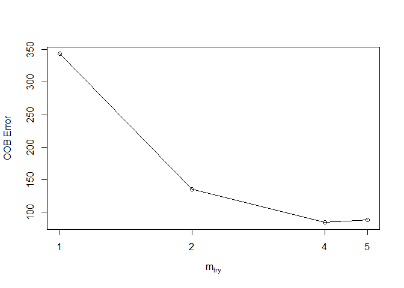

- Thực hiện tối ưu mô hình với m<sub>try</sub> = 2:

```r
rf_sales_model_2 <- randomForest(sales ~ pizza_name + unit_price + pizza_size + pizza_category, data = train_data, mtry = 2)

rf_sales_model_2
```

```
##
## Call:
##  randomForest(formula = sales ~ pizza_name + unit_price + pizza_size +      pizza_category, data = train_data, mtry = 2)
##                Type of random forest: regression
##                      Number of trees: 500
## No. of variables tried at each split: 2
##
##           Mean of squared residuals: 73.17415
##                     % Var explained: 90.42
```

> Từ Mean of squard residuals ta có RMSE bằng khoảng 8.6, giảm 6 đơn vị so với mô hình random forest ban đầu. Và % Var explained bằng 90%, tăng 20%. Chứng tỏ giá trị m<sub>try</sub> = 2 là giá trị phù hợp để tối ưu mô hình.
- Thực hiện tối ưu mô hình với m<sub>try</sub> = 3:

```r
rf_sales_model_3 <- randomForest(sales ~ pizza_name + unit_price + pizza_size + pizza_category, data = train_data, mtry = 3)

rf_sales_model_3
```

```
##
## Call:
##  randomForest(formula = sales ~ pizza_name + unit_price + pizza_size +      pizza_category, data = train_data, mtry = 3)
##                Type of random forest: regression
##                      Number of trees: 500
## No. of variables tried at each split: 3
##
##           Mean of squared residuals: 59.35411
##                     % Var explained: 92.23
```

> Kết quả cho thấy Mean of squard residuals thấp và % Var explained cao hơn cả mô hình có m=2. Chọn đây là mô hình dự đoán cuối cùng.
- Dự đoán doanh số trên tập dữ liệu kiểm tra

```r
predicted_sales <- predict(rf_sales_model_3, newdata = test_data)

head(predicted_sales)
```

```
##        1        2        3        4        5        6
## 38.03152 38.03152 38.03152 38.03152 80.77398 80.77398
```

- Kiểm tra độ chính xác

```r
actual_values <- test_data$sales

# Tính R2 (R-squared)
ss_total <- sum((actual_values - mean(actual_values))^2)
ss_residual <- sum((actual_values - predicted_sales)^2)
r_squared <- 1 - (ss_residual / ss_total)
cat("R-squared: ", r_squared)
```

```
## R-squared:  0.9291224
```

Mô hình đã giải thích được 92% sự biến thiên của sales trong tập dữ liệu kiểm tra.

- Tính toán lỗi RMSE (Root Mean Squared Error)

```r
rmse <- sqrt(mean((predicted_sales - actual_values)^2))
cat("RMSE: ", rmse)
```

```
## RMSE:  7.851516
```

> Mô hình có R-squared cao trên cả tập dữ liệu huấn luyện và tập kiểm tra, nên có thể kết luận rằng mô hình không bị overfitting và đạt hiệu quả dự đoán rất tốt. Bên cạnh đó, sai số dự đoán (RMSE) nhỏ cho thấy đây là mô hình rất đáng tin cậy để dự đoán doanh số.

## 7.3. Dự đoán bằng mô hình GBM

Ở mô hình Random Forest xây dựng các cây quyết định độc lập song song và kết hợp chúng bằng trung bình hoặc biểu quyết đa số, dẫn đến mô hình ít nhạy cảm hơn với lỗi nhưng cũng có thể bỏ qua các mẫu quan trọng. Boosting, với khả năng học có trọng số, có xu hướng phù hợp hơn để nắm bắt các mối quan hệ phi tuyến phức tạp giữa các đặc trưng và mục tiêu, đặc biệt khi dữ liệu có nhiễu hoặc cần tối ưu hóa sâu hơn.

- Tại sao sử dụng mô hình GBM:

Với bài toán dự đoán doanh số bán hàng pizza, GBM là một lựa chọn hợp lý do dữ liệu có nhiều đặc trưng dạng danh mục và mối quan hệ giữa các đặc trưng không hoàn toàn tuyến tính. Khả năng sử dụng các tham số tùy chỉnh như độ sâu cây, tốc độ học, và số cây cũng cho phép chúng em tinh chỉnh mô hình để phù hợp với cấu trúc của dữ liệu này.

- Tạo dataframe phù hợp và thực hiện tiền xử lý để phù hợp với yêu cầu của mô hình GBM.

```r
 sale_data <- df %>%
  mutate(order_month = floor_date(as.Date(order_date), "month")) %>% # ngay dau cua thang
  group_by(pizza_name, unit_price, pizza_size, pizza_category, order_month) %>%
  summarise(sales = sum(quantity), .groups = 'drop')
sale_data
```

```
## # A tibble: 1,091 x 6
##    pizza_name             unit_price pizza_size pizza_category order_month sales
##    <chr>                       <dbl> <fct>      <fct>          <date>      <dbl>
##  1 The Barbecue Chicken ~       12.8 S          Chicken        2015-01-01     37
##  2 The Barbecue Chicken ~       12.8 S          Chicken        2015-02-01     35
##  3 The Barbecue Chicken ~       12.8 S          Chicken        2015-03-01     53
##  4 The Barbecue Chicken ~       12.8 S          Chicken        2015-04-01     34
##  5 The Barbecue Chicken ~       12.8 S          Chicken        2015-05-01     47
##  6 The Barbecue Chicken ~       12.8 S          Chicken        2015-06-01     36
##  7 The Barbecue Chicken ~       12.8 S          Chicken        2015-07-01     53
##  8 The Barbecue Chicken ~       12.8 S          Chicken        2015-08-01     35
##  9 The Barbecue Chicken ~       12.8 S          Chicken        2015-09-01     41
## 10 The Barbecue Chicken ~       12.8 S          Chicken        2015-10-01     32
## # i 1,081 more rows
```

- Chia dữ liệu thành train và test

```r
# Chia dữ liệu thành train và test
set.seed(123)
train_index <- createDataPartition(sale_data$sales, p = 0.8, list = FALSE)
train_data <- sale_data[train_index, ]
test_data <- sale_data[-train_index, ]

train_data <- train_data %>%
  mutate(across(where(is.character), as.factor))
test_data <- test_data %>%
  mutate(across(where(is.character), as.factor))
train_data$order_month <- as.factor(train_data$order_month)
test_data$order_month <- as.factor(test_data$order_month)
```

- Huấn luyện mô hình GBM

```r
set.seed(123)

gbm_model <- gbm(
  formula = sales ~ pizza_name + unit_price + pizza_size + pizza_category + order_month, # Biến đầu vào và đầu ra
  data = train_data,            # Dữ liệu huấn luyện
  distribution = "gaussian",    # Phân phối cho biến đầu ra (ở đây là giá trị liên tục)
  n.trees = 5000,               # Số lượng cây tối đa
  interaction.depth = 5,        # Độ sâu tối đa của cây
  shrinkage = 0.01,             # Hệ số học
  cv.folds = 5,                 # Số lượng tập gấp nếp (cross-validation)
  verbose = FALSE               # Không hiển thị thông báo trong quá trình chạy
)
```

Chúng em sử dụng phân phối “gaussian” cho biến phụ thuộc trong mô hình này vì “gaussian” được sử dụng khi biến đầu ra là một giá trị liên tục (ví dụ, giá trị dự đoán cho sales là một số thực). Đây là lựa chọn chuẩn cho các bài toán hồi quy.

- Xem thông tin về relative influence của các đặc trưng:

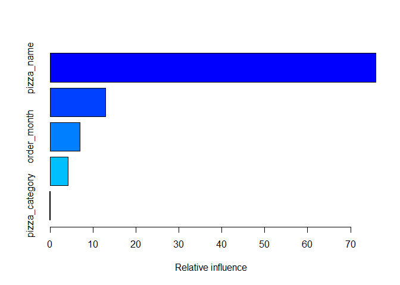

```
##                           var     rel.inf
## pizza_name         pizza_name 75.91575321
## unit_price         unit_price 12.93152761
## order_month       order_month  6.94657858
## pizza_size         pizza_size  4.13528351
## pizza_category pizza_category  0.07085709
```

```r
summary (gbm_model)
```

### Tối hóa ưu mô hình

- Loại bỏ biến độc lập pizza_category

```r
set.seed(123)
# Huấn luyện mô hình GBM
gbm_model <- gbm(
  formula = sales ~ pizza_name + unit_price + pizza_size  + order_month, # Biến đầu vào và đầu ra
  data = train_data,            # Dữ liệu huấn luyện
  distribution = "gaussian",    # Phân phối cho biến đầu ra (ở đây là giá trị liên tục)
  n.trees = 5000,               # Số lượng cây tối đa
  interaction.depth = 5,        # Độ sâu tối đa của cây
  shrinkage = 0.01,             # Hệ số học
  cv.folds = 5,                 # Số lượng tập gấp nếp (cross-validation)
  verbose = FALSE               # Không hiển thị thông báo trong quá trình chạy
)
```

- Xác định số lượng cây tối ưu dựa trên kĩ thuật cross-validation

Việc chọn số lượng cây tối ưu rất quan trọng, vì nếu số lượng cây quá ít, mô hình sẽ chưa đủ mạnh để học các mẫu dữ liệu phức tạp; nếu quá nhiều cây, mô hình có thể trở nên quá phức tạp và dễ bị overfitting.

Em sẽ dựa vào Cross-validation loss để tính số lượng cây tối ưu vì nó phản ánh khả năng tổng quát của mô hình đối với dữ liệu chưa được huấn luyện, giúp đánh giá mô hình một cách khách quan và tránh overfitting.

```r
best_trees <- gbm.perf(gbm_model, method ="cv")
```

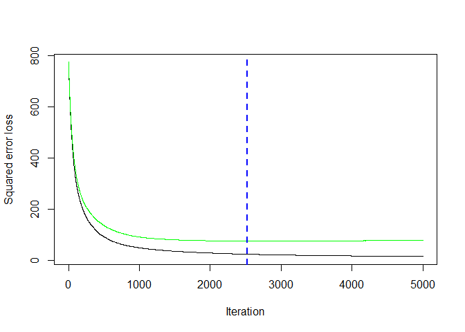

- Dự đoán trên tập kiểm tra với best trees

```r
predictions <- predict(gbm_model, test_data, n.trees = best_trees)
```

- Kiểm tra tính chính xác của mô hình GBM

```r
# Tính toán R-squared và RMSE
actual <- test_data$sales # Giá trị thực tế
predicted <- predictions  # Giá trị dự đoán từ mô hình

# Tính R-squared
ss_total <- sum((actual - mean(actual))^2)  # Tổng bình phương sai số so với giá trị trung bình
ss_residual <- sum((actual - predicted)^2) # Tổng bình phương sai số của dự đoán
r_squared <- 1 - (ss_residual / ss_total)

# Tính RMSE
rmse <- sqrt(mean((actual - predicted)^2))

# Kết quả
cat("R-squared:", r_squared, "\n")
```

```
## R-squared: 0.9187589
```

```r
cat("RMSE:", rmse, "\n")
```

```
## RMSE: 8.036842
```

- Trực quan hóa độ chính xác trong mô hình

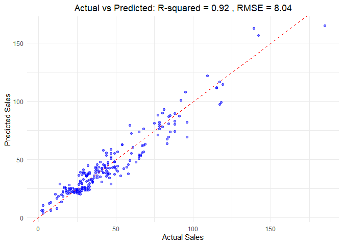

```r
results <- data.frame(
  Actual = actual,
  Predicted = predicted
)

# Vẽ biểu đồ dự đoán so với giá trị thực tế
ggplot(results, aes(x = Actual, y = Predicted)) +
  geom_point(color = 'blue', alpha = 0.5) +  # Dữ liệu điểm
  geom_abline(slope = 1, intercept = 0, color = "red", linetype = "dashed") +  # Đường chuẩn (y = x)
  labs(title = paste("Actual vs Predicted: R-squared =", round(r_squared, 2), ", RMSE =", round(rmse, 2)),
       x = "Actual Sales",
       y = "Predicted Sales") +
  theme_minimal() +
  theme(plot.title = element_text(hjust = 0.5))
```

Mô hình Gradient Boosting Machine (GBM) dự đoán doanh số bán pizza đã đạt được hiệu quả cao, thể hiện qua giá trị R-squared là 0.92, cho thấy mô hình giải thích được 92% biến thiên của dữ liệu. Giá trị Root Mean Squared Error (RMSE) là 8.04, cho thấy sai số trung bình giữa giá trị dự đoán và giá trị thực tế là khoảng 8 đơn vị. Kết quả này chứng tỏ mô hình có độ chính xác rất tốt.

## 7.4. Kết luận

Trong bài toán này, mô hình hồi quy tuyến tính có độ chính xác thấp nhất (~67%), trong khi hai mô hình Random forest và GBM đều cho sai số dự đoán nhỏ tương đương nhau và đều có độ chính xác cao khoảng 92%. Vì vậy, em chọn random forest là mô hình cuối cùng dùng để dự đoán doanh số của sản phẩm. Quyết định này là do khi hai mô hình có hiệu suất tương đương thì nên chọn mô hình đơn giản hơn để dễ hiểu, bảo trì, triển khai, ít nguy cơ overfitting và yêu cầu ít tài nguyên tính toán hơn. Trong bài toán này, Random forest có khả năng tổng quát hóa tốt hơn mà không cần điều chỉnh quá nhiều, và các cây quyết định của nó được xây dựng một cách độc lập với nhau nên có tốc độ huấn luyện nhanh và ít nhạy cảm với nhiễu trong tập dữ liệu hơn mô hình GBM.  
Ngoài ra, mô hình random forest sau khi được tối ưu đã dự đoán doanh số của sản phẩm tốt hơn rất nhiều so với mô hình hồi quy tuyến tính vì nó có khả năng nắm bắt các mối quan hệ phi tuyến tính và tương tác phức tạp giữa các biến độc lập mà mô hình hồi quy tuyến tính chưa mô tả được. Mô hình random forest còn có khả năng xử lý hiệu quả biến phân loại nhiều mức một cách tự nhiên khi xây dựng các cây quyết định, trong khi đó mô hình hồi quy tuyến tính sẽ dùng kỹ thuật one hot encoding để tạo biến giả, tăng độ phức tạp của mô hình và có thể gây ra vấn đề đa cộng tuyến. Hơn nữa, random forest ít bị ảnh hưởng bởi giá trị ngoại lai (outliers) nhờ lấy trung bình của nhiều cây quyết định, và không yêu cầu các giả định phân phối nghiêm ngặt, phù hợp với tính chất dữ liệu trong bài toán này.

# Phần 8. Dự đoán doanh thu trong 6 tháng tiếp theo bằng mô hình ARIMA:

Mục tiêu của mô hình là dự báo doanh thu theo ngày của chuỗi doanh thu theo ngày(revenue_ts_date) từ dữ liệu được khai thác trong giai đoạn từ 01/01/2015 đến 20/12/2015 theo phương pháp ARIMA.

- Mô hình sử dụng đầu vào chính là những tín hiệu quá khứ của chuỗi được dự báo để dự báo nó.
- Khi xây dựng mô hình ARIMA, cần phải xem xét tham số p,d,q. Đầu tiên cần phải lựa chọn tham số phù hợp cho mô hình ARIMA (p,d,q):
  - p: Số bậc của phần tự hồi quy (Auto-Regressive). Nó đại diện cho số lượng các giá trị trước đó của chuỗi thời gian được sử dụng để dự đoán giá trị hiện tại.
  - d: Bậc sai phân cần thực hiện để chuỗi thời gian trở nên dừng (stationary). Chuỗi thời gian được gọi là dừng nếu giá trị kỳ vọng và phương sai của nó không thay đổi theo thời gian. Sai phân giúp loại bỏ xu hướng (trend) và tính mùa vụ (seasonality) trong dữ liệu. d đại diện cho số lần sai phân để chuỗi thời gian trở nên dừng.  
    Phép sai phân là quá trình tính toán hiệu số giữa các giá trị liên tiếp trong chuỗi thời gian. Phép sai phân là quá trình tính toán hiệu số giữa các giá trị liên tiếp trong chuỗi thời gian.
  - q: Số bậc của phần trung bình trượt (Moving Average).Nó đại diện cho số các nhiễu (error terms) trong quá khứ được sử dụng để dự đoán giá trị hiện tại.
- Đầu tiên, cần kiểm tra tính dừng của chuỗi thời gian:  
  Một chuỗi thời gian dừng có các đặc tính thống kê như trung bình và phương sai không thay đổi theo thời gian, điều này rất quan trọng cho việc xây dựng các mô hình dự báo như ARIMA. Kiểm tra tính dừng bằng ADF test (Augmented Dickey-Fuller):

```r
adf_test <- adf.test(revenue_ts_date)
print(adf_test)
```

```
##
##  Augmented Dickey-Fuller Test
##
## data:  revenue_ts_date
## Dickey-Fuller = -5.4062, Lag order = 7, p-value = 0.01
## alternative hypothesis: stationary
```

**Kết quả kiểm định**:  
Giá trị thống kê ADF (Dickey-Fuller statistic): -5.4062 - giá trị âm lớn (xa 0) thường gợi ý chuỗi có tính dừng. Lag order = 7 - số độ trễ được sử dụng trong kiểm định để xử lý tự tương quan.  
Giá trị p-value < 0.05, chúng ta bác bỏ giả thuyết 0 rằng chuỗi thời gian không dừng. Nghĩa là chấp nhận giả thuyết chuỗi thời gian dừng.

> Chuỗi thời gian dừng nên lấy d = 0
- Xác định p, q dựa vào ACF (Auto-Correlation Function) và PACF (Partial Auto-Correlation Function):  
  Xác định hệ số tự tương quan (AFC) thông qua biểu đồ AFC. ACF đo lường tương quan giữa các quan sát hiện tại và các quan sát trễ (lags)

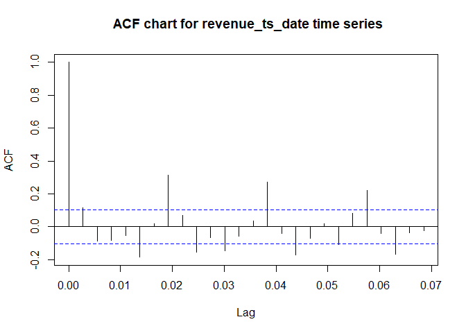

```r
# Vẽ biểu đồ ACF cho chuỗi thời gian revenue_ts_date
acf(revenue_ts_date, main = " ACF chart for revenue_ts_date time series")
```

- Xác định p thông qua biểu đồ PACF:

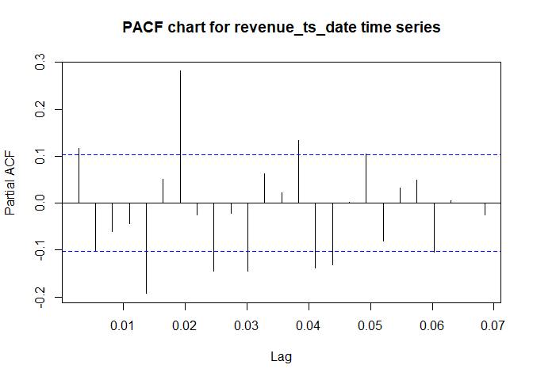

```r
pacf(revenue_ts_date, main = "PACF chart for revenue_ts_date time series")
```

```r
auto_model <- auto.arima(revenue_ts_date, stepwise=FALSE, approximation=FALSE)
summary(auto_model)
```

```
## Series: revenue_ts_date
## ARIMA(2,0,2) with non-zero mean
##
## Coefficients:
##          ar1      ar2      ma1     ma2       mean
##       1.0875  -0.9354  -0.9789  0.9126  2284.8784
## s.e.  0.0350   0.0291   0.0358  0.0413    22.4314
##
## sigma^2 = 150622:  log likelihood = -2640.06
## AIC=5292.13   AICc=5292.37   BIC=5315.41
##
## Training set error measures:
##                     ME     RMSE      MAE       MPE     MAPE MASE        ACF1
## Training set 0.1656159 385.3801 282.4625 -2.668544 12.66522  NaN -0.03801733
```

Dùng stepwise=FALSE để tìm kiếm tăng độ chính xác trong việc tìm kiếm mô hình nhưng tiêu tốn thời gian tính toán nhiều hơn.  
Approximation=FALSE sử dụng phương pháp chính xác (exact likelihood estimation), đảm bảo mô hình được chọn là tốt nhất dựa trên các tiêu chí như AIC, AICc, hoặc BIC, nhưng thời gian tính toán sẽ tăng đáng kể.

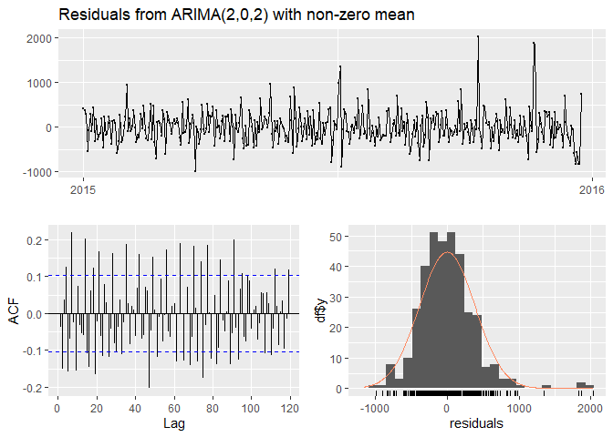

```
##
##  Ljung-Box test
##
## data:  Residuals from ARIMA(2,0,2) with non-zero mean
## Q* = 313.92, df = 68, p-value < 2.2e-16
##
## Model df: 4.   Total lags used: 72
```

```r
# Kiểm tra phần dư của mô hình ARIMA
checkresiduals(auto_model)
```

Kết quả kiểm định: p-value < 0.05: Chúng ta bác bỏ giả thuyết gốc, nghĩa là phần dư vẫn có tự tương quan. Điều này gợi ý rằng mô hình ARIMA(2,0,2) chưa đủ để mô hình hóa hoàn toàn dữ liệu, và có thể cần điều chỉnh hoặc thử nghiệm thêm các cấu trúc mô hình khác.  
Phân phối phần dư dường như hơi lệch với đuôi dài, đặc biệt có một số phần dư cực lớn. Điều này cho thấy phân phối của phần dư không hoàn toàn tuân theo chuẩn. Các giá trị tự tương quan của phần dư không nằm hoàn toàn trong giới hạn tin cậy (đường chấm xanh), đặc biệt ở một số độ trễ (lags).

- Kiểm tra lại với các mô hình ARIMA khác nhau:

```r
# ARIMA(2,0,0)
model_200 <- arima(revenue_ts_date, order = c(2, 0, 0))
summary(model_200)
```

```
##
## Call:
## arima(x = revenue_ts_date, order = c(2, 0, 0))
##
## Coefficients:
##          ar1      ar2  intercept
##       0.1304  -0.1050  2284.7566
## s.e.  0.0528   0.0532    21.7181
##
## sigma^2 estimated as 160330:  log likelihood = -2653.31,  aic = 5314.62
##
## Training set error measures:
##                      ME     RMSE      MAE       MPE     MAPE     MASE
## Training set 0.09082499 400.4121 288.7523 -2.870291 12.89331 0.709651
##                      ACF1
## Training set -0.006234676
```

```r
# ARIMA(2,0,2)
model_202 <- arima(revenue_ts_date, order = c(2, 0, 2))
summary(model_202)
```

```
##
## Call:
## arima(x = revenue_ts_date, order = c(2, 0, 2))
##
## Coefficients:
##          ar1      ar2      ma1     ma2  intercept
##       1.0875  -0.9354  -0.9789  0.9126  2284.8784
## s.e.  0.0350   0.0291   0.0358  0.0413    22.4314
##
## sigma^2 estimated as 148518:  log likelihood = -2640.06,  aic = 5292.13
##
## Training set error measures:
##                     ME     RMSE      MAE       MPE     MAPE      MASE
## Training set 0.1656159 385.3801 282.4625 -2.668544 12.66522 0.6941928
##                     ACF1
## Training set -0.03801733
```

```r
# ARIMA(5,0,0)
model_500 <- arima(revenue_ts_date, order = c(5, 0, 0))
summary(model_500)
```

```
##
## Call:
## arima(x = revenue_ts_date, order = c(5, 0, 0))
##
## Coefficients:
##          ar1      ar2      ar3      ar4      ar5  intercept
##       0.1143  -0.1146  -0.0818  -0.0279  -0.2081  2285.7026
## s.e.  0.0519   0.0527   0.0531   0.0530   0.0532    15.7219
##
## sigma^2 estimated as 152706:  log likelihood = -2644.72,  aic = 5303.43
##
## Training set error measures:
##                     ME     RMSE     MAE      MPE     MAPE      MASE        ACF1
## Training set 0.6279265 390.7767 283.439 -2.73931 12.74767 0.6965928 0.008695046
```

```r
# ARIMA(2,1,2)
model_212 <- arima(revenue_ts_date, order = c(2, 1, 2))
summary(model_212)
```

```
##
## Call:
## arima(x = revenue_ts_date, order = c(2, 1, 2))
##
## Coefficients:
##          ar1      ar2      ma1     ma2
##       0.7418  -0.1873  -1.6195  0.6195
## s.e.  0.1954   0.0537   0.1948  0.1947
##
## sigma^2 estimated as 159136:  log likelihood = -2647.68,  aic = 5305.35
##
## Training set error measures:
##                     ME     RMSE      MAE       MPE     MAPE      MASE
## Training set -7.605044 398.3611 285.8956 -3.185408 12.85534 0.7026303
##                      ACF1
## Training set -0.003409274
```

> So sánh các chỉ số AIC cho thấy mô hình ARIMA (2,0,2) vẫn tốt hơn (do có chỉ số AIC thấp nhất).

Sau khi đã tìm ra được mô hình ARIMA tốt nhất. Chúng ta sẽ dự báo cho khoảng thời gian tiếp theo.

- Dự đoán doanh thu trong 6 tháng (180 ngày) tiếp theo. Do điểm dữ liệu doanh thu theo tháng quá ít để xây dựng mô hình, nên sẽ dự đoán theo ngày, với số ngày là 180 ngày.

```r
forecast_values <- forecast(auto_model, h = 180, level = c(80))
# Hiển thị dự đoán
print(forecast_values)
```

```
##           Point Forecast    Lo 80    Hi 80
## 2015.9808       2372.271 1874.901 2869.641
## 2015.9836       2458.613 1958.317 2958.908
## 2015.9863       2392.074 1889.537 2894.611
## 2015.9890       2238.946 1736.408 2741.484
## 2015.9918       2134.654 1630.260 2639.049
## 2015.9945       2164.470 1657.799 2671.141
## 2015.9973       2294.449 1787.643 2801.256
## 2016.0000       2407.918 1900.094 2915.741
## 2016.0027       2409.735 1899.842 2919.629
## 2016.0055       2305.574 1795.293 2815.855
## 2016.0082       2190.594 1679.868 2701.320
## 2016.0110       2162.982 1650.551 2675.414
## 2016.0137       2240.506 1727.440 2753.571
## 2016.0164       2350.643 1837.452 2863.834
## 2016.0192       2397.906 1883.440 2912.372
## 2016.0219       2346.284 1831.015 2861.552
## 2016.0247       2245.933 1730.658 2761.208
## 2016.0274       2185.085 1668.954 2701.216
## 2016.0301       2212.779 1695.784 2729.774
## 2016.0329       2299.815 1782.798 2816.831
## 2016.0356       2368.564 1851.043 2886.085
## 2016.0384       2361.918 1843.572 2880.264
## 2016.0411       2290.382 1771.931 2808.833
## 2016.0438       2218.801 1700.104 2737.499
## 2016.0466       2207.869 1688.460 2727.277
## 2016.0493       2262.936 1743.324 2782.549
## 2016.0521       2333.050 1813.350 2852.751
## 2016.0548       2357.792 1837.537 2878.047
## 2016.0575       2319.114 1798.575 2839.654
## 2016.0603       2253.908 1733.355 2774.461
## 2016.0630       2219.172 1698.228 2740.117
## 2016.0658       2242.391 1721.121 2763.660
## 2016.0685       2300.133 1778.862 2821.404
## 2016.0712       2341.211 1819.695 2862.727
## 2016.0740       2331.873 1810.031 2853.716
## 2016.0767       2283.293 1761.426 2805.161
## 2016.0795       2239.195 1717.197 2761.194
## 2016.0822       2236.679 1714.387 2758.971
## 2016.0849       2275.192 1752.837 2797.547
```

[output cut: 126 more lines]

```
## 2016.4329       2284.285 1759.931 2808.640
## 2016.4356       2284.215 1759.860 2808.570
## 2016.4384       2284.712 1760.357 2809.066
## 2016.4411       2285.318 1760.963 2809.672
## 2016.4438       2285.512 1761.157 2809.867
## 2016.4466       2285.157 1760.802 2809.511
## 2016.4493       2284.588 1760.234 2808.943
## 2016.4521       2284.303 1759.948 2808.657
## 2016.4548       2284.524 1760.169 2808.878
## 2016.4575       2285.031 1760.676 2809.386
## 2016.4603       2285.376 1761.022 2809.731
## 2016.4630       2285.277 1760.922 2809.632
## 2016.4658       2284.846 1760.491 2809.201
## 2016.4685       2284.470 1760.116 2808.825
## 2016.4712       2284.465 1760.110 2808.820
```

- Trực quan hóa số liệu dự đoán:

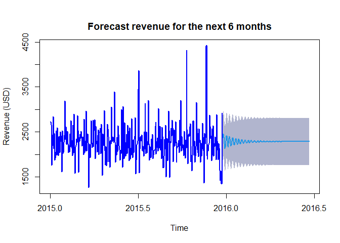

```r
plot(forecast_values, main = "
Forecast revenue for the next 6 months", xlab = "Time", ylab = "Revenue (USD)")
lines(revenue_ts_date, col = "blue", lwd = 2)
```

**Nhận xét:**

1. Xu hướng dự báo: Doanh thu pizza trong 6 tháng dự báo có xu hướng ổn định, không tăng hoặc giảm mạnh theo thời gian. Điều này thể hiện qua đường trung bình (màu xanh), dao động quanh một mức giá trị cố định, không có sự thay đổi đáng kể về xu hướng.
2. Biến động của dữ liệu: Trong dữ liệu lịch sử, doanh thu pizza có những giai đoạn dao động lớn và xuất hiện các đỉnh cao đột ngột. Tuy nhiên, dự báo không phản ánh các biến động lớn đó, mà chỉ nhắm đến mức trung bình chung, làm giảm khả năng dự đoán các đột biến doanh thu (nếu có).
3. Về độ tin cậy: Với khoảng tin cậy khá rộng, đặc biệt ở cuối giai đoạn dự báo, điều này có thể ám chỉ rằng mô hình gặp khó khăn trong việc nắm bắt toàn bộ đặc điểm của dữ liệu, đặc biệt là những biến động bất thường trong lịch sử. Do đó, dự đoán này nên được sử dụng thận trọng, đặc biệt trong việc ra quyết định dài hạn.
4. Ổn định: Nếu xu hướng trung bình tiếp tục, doanh nghiệp có thể dự đoán doanh thu tương đối ổn định mà không cần phải đối mặt với biến động lớn trong ngắn hạn nhưng cũng có rủi ro tiềm ẩn: Các sự kiện bất thường (như khuyến mãi, nhu cầu mùa cao điểm) có thể không được phản ánh đầy đủ trong mô hình. Điều này cần được cân nhắc khi lập kế hoạch kinh doanh.

# Phần 9. Kết luận:

Mục tiêu của đề tài là thực hiện bài toán phân tích dữ liệu và xây dựng mô hình dự đoán với ngôn ngữ R trên tập dữ liệu bán hàng của một cửa hàng pizza. Đồ án của nhóm đã đạt được mục tiêu đề ra bằng cách: Hiểu dữ liệu và bài toán; Tiền xử lý dữ liệu như kiểm tra giá trị thiếu, chuyển sang kiểu dữ liệu phù hợp, tạo các biến mới cần thiết…; Cung cấp các đánh giá và trực quan hóa kết quả phân tích nhu cầu tiêu thụ pizza, nguyên liệu, doanh số, doanh thu bằng nhiều loại biểu đồ đa dạng; Xây dựng được mô hình dự đoán doanh số với độ chính xác cao và sai số nhỏ; Dự đoán doanh thu trong 6 tháng tiếp theo bằng mô hình ARIMA. Mặc dù đồ án đã sử dụng một tập dữ liệu khá lớn, tuy nhiên thông tin dữ liệu là từ các đơn đặt hàng pizza trong năm 2015, mang tính chất thực hành phân tích. Ngoài ra, tập dữ liệu chứa ít thông tin về khách hàng, gây khó khăn trong việc thực hiện các phân tích liên quan như phân khúc khách hàng, phân tích hành vi mua sắm. Qua những hạn chế đã đề cập, để phát triển đề tài này nhóm có thể thu thập nhiều thông tin liên quan đến khách hàng, sử dụng dữ liệu mới nhất từ các hệ thống bán hàng thời gian thực nhằm nâng cao giá trị của các phân tích.

# Phần 10. Tài liệu tham khảo:

1. Winton Clem (2024), Analysis of Data and the Field of Data Science, First edition
2. Peter J. Brockwell & Richard A. Davis (2002), Introduction to Time Series and Forecasting, 2nd ed, Nxb. Springer.
3. Joshua Noble, What are ARIMA models?, ibm.com, https://www.ibm.com/topics/arima-model, truy cập ngày 10/11/2024.
4. G.E. Box, G.M. Jenkins, G.C. Reinsel and G.M. Ljung (2016), Time series analysis: forecasting and control, 4th ed, John Wiley & Sons.
5. Phạm Đình Khánh (2019), Mô hình ARIMA trong time series, https://phamdinhkhanh.github.io/2019/12/12/ARIMAmodel.html#42-ch%E1%BB%89-s%E1%BB%91-aic---akaike-information-criteria, truy cập ngày 12/11/2024.
6. Prabhakaran Selva (2019), ARIMA Model – Complete Guide to Time Series Forecasting in Python, Machine Learning Plus, machinelearningplus.com, https://www.machinelearningplus.com/time-series/arima-model-time-series-forecasting-python/, truy cập ngày 15/11/2024.
7. Deepanshu Bhalla, Random Forest in R: A Step-by-Step Guide, Listen Data, https://www.listendata.com/2014/11/random-forest-with-r.html, truy cập ngày 10/11/2024
8. Rebecca Bevans (2020), ANOVA in R, Scribbr, https://www.scribbr.com/statistics/anova-in-r/, truy cập ngày 04/11/2024. 9.Zach Bobbitt (2022), How to Perform a Kruskal-Wallis Test in R, Statology, https://www.statology.org/kruskal-wallis-test-in-r/, truy cập ngày 10/11/2024.

# Phần 11. Đóng góp:

## 11.1. Bảng phân công nhiệm vụ

| STT | Mã SV | Họ và tên | Nhiệm vụ |
| --- | --- | --- | --- |
| 1 | 22133017 | Nguyễn Thị Ngọc Hân | - Lập kế hoạch và Phân công. - Viết tóm tắt (Phần 1). - Viết giới thiệu (Phần 2). - Phân tích doanh số (6.4). - Dự đoán doanh số bằng mô hình hồi quy tuyến tính (7.1) và random forest (7.2); Kết luận … |
| 2 | 22133020 | Nguyễn Hoàng | - Phân tích nhu cầu tiêu thụ pizza theo thời gian (6.2) - Phân tích nguyên liệu (6.3). - Viết kết luận (Phần 9). - Tổng hợp file Word. |
| 3 | 22133043 | Võ Triệu Phúc | - Thông tin về tập dữ liệu (Phần 4). - Tiền xử lý dữ liệu (Phần 5) - Dự đoán doanh số bằng mô hình GBM (7.3). |
| 4 | 22151305 | Nguyễn Thị Hồng Thơ | - Phân tích tổng quan dữ liệu (6.1). - Phân tích doanh thu (6.5). - Dự đoán doanh thu theo thời gian (Phần 8). - Tổng hợp file PowerPoint. |

## 11.2. Thành viên nhận xét và đánh giá

### Nguyễn Thị Ngọc Hân

| Thành viên | Nhận xét | Đánh giá (%) |
| --- | --- | --- |
| Nguyễn Hoàng | Hoàn thành đúng tiến độ. Sử dụng đa dạng biểu đồ, nhận xét các biểu đồ rất chi tiết. | 100 |
| Võ Triệu Phúc | Hoàn thành nhiệm vụ nhưng hay trễ hạn của nhóm. | 95 |
| Nguyễn Thị Hồng Thơ | Hoàn thành nhiệm vụ và đưa ra nhận xét rất chi tiết. | 100 |

### Nguyễn Hoàng

| Thành viên | Nhận xét | Đánh giá (%) |
| --- | --- | --- |
| Nguyễn Thị Ngọc Hân | Phân công việc cụ thể cho thành viên, đảm bảo tiến độ của nhóm. Phân tích và trực quan rõ ràng, chi tiết các yếu tố ảnh hưởng đến doanh số. Đưa ra đánh giá và kết luận về mô hình chi tiết; mô hình đượ… | 100 |
| Võ Triệu Phúc | Hoàn thành tốt nhiệm vụ, làm sạch và xử lý được dữ liệu dư thừa chuẩn bị cho phân tích và xây dựng mô hình | 100 |
| Nguyễn Thị Hồng Thơ | Trực quan hóa rõ ràng, phân tích, đánh giá doanh thu chi tiết theo các khoảng thời gian khác nhau. Xây dựng mô hình ARIMA chi tiết với các trực quan, nhận xét và giải thích cho các tham số thống kê; k… | 100 |

### Võ Triệu Phúc

| Thành viên | Nhận xét | Đánh giá (%) |
| --- | --- | --- |
| Nguyễn Thị Ngọc Hân | Phân công việc cụ thể cho thành viên, đảm bảo tiến độ của nhóm. Hoàn thành tốt nhiệm vụ. | 100 |
| Nguyễn Hoàng | Hoàn thành đúng tiến độ. Nhận xét biểu đồ rất chi tiết. | 100 |
| Nguyễn Thị Hồng Thơ | Hoàn thành đúng tiến độ, phân tích và tổng hợp được các thông tin quan trọng từ tập dữ liệu. Xây dựng mô hình ARIMA chi tiết với các trực quan, nhận xét và giải thích cho các tham số thống kê; kiểm tr… | 100 |

### Nguyễn Thị Hồng Thơ

| Thành viên | Nhận xét | Đánh giá (%) |
| --- | --- | --- |
| Nguyễn Hoàng | Hoàn thành đúng tiến độ. Nhận xét biểu đồ rất chi tiết | 100 |
| Võ Triệu Phúc | Thực hiện nhiệm vụ rõ ràng, chi tiết | 100 |
| Nguyễn Thị Ngọc Hân | Phân công việc cụ thể cho nhóm, kiểm tra lại các việc thường xuyên. Hoàn thành đúng tiến độ. Đưa ra đánh giá và kết luận về mô hình chi tiết. | 100 |